# Tutorial for Functions.py

Minimization of the full loss function ($\alpha,\beta,\gamma$ hyperparameters) through nested minimization.

It includes also the optimization of force fields (corresponding to $\alpha,\gamma=\infty$) with data from alchemical $\Delta G$ calculations.

Customized algorithm.

- see https://pubs.aip.org/aip/jcp/article/158/21/214120/2894410 for refinement with only $\alpha,\gamma$ finite and https://pubs.acs.org/doi/full/10.1021/acs.jpclett.3c03423 for refinement with only $\alpha,\beta$ finite;
- see https://pubs.acs.org/doi/full/10.1021/acscentsci.2c00565 for refinement with alchemical calculations (L2 regularization).

```python
import numpy as np
import jax.numpy as jnp
import pandas
import matplotlib
import matplotlib.pyplot as plt
from IPython.display import clear_output
```

import from parent directory

```python
import sys
sys.path.append('../')
```

```python
from MDRefine import load_data, minimizer, select_traintest, hyper_minimizer, MDRefinement
```

a simple script to unwrap dictionaries:

```python
def unwrap_dict(d):

    res = []

    if isinstance(d, dict):
        for val in d.values():
            res.extend(unwrap_dict(val))
    else:
        if isinstance(d, list): res = d
        else: res = [d]

    return np.hstack(res)
```

## 1. Ensemble refinement

### a. Load data

Define **infos** dictionary, which specifies required information in order to get data from input files through **load_data**.

see also load_data.ipynb

#### Load observables

(e.g., no force-field terms and no forward quantities)

```python
infos = {}

# Firstly, define global properties, valid for all the systems:

infos['global'] = {}

# 'name of the folder with data'
infos['global']['path_directory'] = '../../DATA'

# system names
system_names = ['AAAA', 'CAAU']  # , 'CCCC', 'GACC', 'UUUU', 'UCAAUC']
infos['global']['system_names'] = system_names

# Then, define properties which are specific of each system, like experimental data and observables

for name in system_names:
    infos[name] = {}

    # experimental observables (average and uncertainty), corresponding to 'file_name'.npy in DATA/system_name/g_exp/
    # uNOEs values are upper bounds, so specify '<' with ('uNOEs','<')
    infos[name]['g_exp'] = ['NOEs', ('uNOEs','<')]

    # observables from MD simulations, corresponding to 'file_name'.npy in DATA/system_name/observables/
    # they must correspond also to items of infos[name]['g_exp']
    infos[name]['obs'] = ['NOEs', 'uNOEs']

# If some properties are the same for all the systems, you can store them just once in infos['global']

infos['global']['temperature'] = 1 # namely, energies are in unit of k_B T (default value)
# (in this case, you could do this also for 'g_exp' and 'obs')

# Select the stride for the frames (thinner strides will require more time for minimizations; default value = 1)
stride = 1000
```

```python
data = load_data(infos, stride = stride)
```

```
WARNING:absl:No GPU/TPU found, falling back to CPU. (Set TF_CPP_MIN_LOG_LEVEL=0 and rerun for more info.)
```

```
loading data from directory...
loading  AAAA
loading  CAAU
done
```

#### Include also quantities computed through a **forward model**.

Besides previously defined **infos**:

```python
for name in system_names:
    # include experimental values also for 3J scalar couplings
    infos[name]['g_exp'] = ['backbone1_gamma_3J', 'backbone2_beta_epsilon_3J', 'sugar_3J', 'NOEs', ('uNOEs','<')]

    # include quantities required to compute observables through the forward model
    # they must correspond to 'file_name'.npy in DATA/system_name/forward_qs/
    infos[name]['forward_qs'] = ['backbone1_gamma','backbone2_beta_epsilon','sugar']

# starting values of the forward model coefficients: specify the file name inside DATA/
infos['global']['forward_coeffs'] = 'original_fm_coeffs' # string
```

Now, define the **forward_model**.

In our case-study, the forward model is given by the **Karplus equations**:

$^3 J_\gamma = A_\gamma \, cos^2\gamma \, + \, B_\gamma \, cos\gamma \, + \, C_\gamma$

with empirical coefficients $A_\gamma,\,B_\gamma,\,C_\gamma$ ($\gamma$ dihedral angles), and analogously for $^3 J_{\beta/\epsilon}$ (same coefficients both for $\beta$ and $\epsilon$ dihedral angles) and $^3J_\nu$ (sugar dihedral angles).

**WARNING**: keys of **forward_qs_out** must correspond to associated g_exp, as specified in infos

```python
def forward_model_fun(fm_coeffs, forward_qs, selected_obs = None):

    # 1. compute the cosine (which is the quantity you need in the forward model;
    # you could do this just once before loading data)
    forward_qs_cos = {}

    for type_name in forward_qs.keys():
        forward_qs_cos[type_name] = np.cos(forward_qs[type_name])

    # if you have selected_obs, compute only the corresponding observables
    if selected_obs is not None:
        for type_name in forward_qs.keys():
            forward_qs_cos[type_name] = forward_qs_cos[type_name][:,selected_obs[type_name+'_3J']]

    # 2. compute observables (forward_qs_out) through forward model
    forward_qs_out = {
        'backbone1_gamma_3J': fm_coeffs[0]*forward_qs_cos['backbone1_gamma']**2 + fm_coeffs[1]*forward_qs_cos['backbone1_gamma'] + fm_coeffs[2],
        'backbone2_beta_epsilon_3J': fm_coeffs[3]*forward_qs_cos['backbone2_beta_epsilon']**2 + fm_coeffs[4]*forward_qs_cos['backbone2_beta_epsilon'] + fm_coeffs[5],
        'sugar_3J': fm_coeffs[6]*forward_qs_cos['sugar']**2 + fm_coeffs[7]*forward_qs_cos['sugar'] + fm_coeffs[8]}

    return forward_qs_out
```

same forward-model function for each system, so put it in infos['global']

```python
infos['global']['forward_model'] = forward_model_fun
```

```python
data = load_data(infos, stride = stride)
```

```
loading data from directory...
loading  AAAA
loading  CAAU
done
```

### b. Minimize the loss function and analyse the results

for a single choice of the hyper-parameter $\alpha$

```python
# use function minimizer with selected data and alpha as input
Result = minimizer(data, alpha=1)
```

Let's look at the values contained in the class **Result**

```python
print(vars(Result).keys())
```

```
dict_keys(['loss', 'min_lambdas', 'minis', 'time', 'D_KL_alpha', 'abs_difference', 'av_g', 'chi2', 'logZ_new', 'weights_new'])
```

**Comments on the minimization.**

As shown in *Andrea Cesari et al., JCTC 2016*, the optimal ensemble $P$ which minimizes the loss function

$\mathcal{L}[P] = \frac{1}{2}\chi^2[P]+\alpha D_{KL}[P|P_0]$

is $P_{\vec\lambda^*}(x) = \frac{1}{Z_{\vec\lambda^*}} P_0(x) e^{-\vec\lambda^*\cdot\vec g(x)}$ where $\vec\lambda^*$ is the point of minimum of the following function

$\Gamma(\vec\lambda) = \frac{1}{2}\alpha\sum_j\sigma_j^2\lambda_j^2+\log Z_{\vec\lambda}+\vec\lambda\cdot\vec{g}_{exp},$

which fulfils $\mathcal L(P_{\vec\lambda^*}) = -\alpha\Gamma(\vec\lambda^*)$ and

$\lambda_i^* = \frac{\langle g_i \rangle_{P_*}-g_{i,exp}}{\alpha\sigma_{i,exp}^2}$.

The Python function **minimizer** exploits this relationship by minimizing $\Gamma$ (for each system), and then evaluating in detail $\mathcal{L}[P_\lambda]$ at the optimal point found for $\Gamma$ (in order to get $\chi^2$ and $D_{KL}$). To check the success of the minimization of $\Gamma$, you can read the truth value *success of inner minimization* (output message of scipy.optimize.minimize, in **Result.minis[name_sys].success**). The quality of this result is determined by comparing $-\alpha\Gamma(\vec\lambda^*)$ with $\mathcal L(P_{\vec\lambda^*})$, which we know to be equal at the point of minimum; this is reported in **Result.abs_difference**.

```python
for name_sys in data.properties.system_names:
    print(Result.minis[name_sys].success, Result.minis[name_sys].message)

print('\nabsolute differences:\n', Result.abs_difference)
```

```
True Optimization terminated successfully.
True Optimization terminated successfully.

absolute differences:
 {'AAAA': DeviceArray(0.00567539, dtype=float64), 'CAAU': DeviceArray(0.00401629, dtype=float64)}
```

- first of all, the min. value of the loss function **loss**

```python
print('optimal loss: ', Result.loss)
print('time required: ', Result.time)
```

```
optimal loss:  157.40786286559697
time required:  22.592878818511963
```

- then, the optimal ensembles $P^*$ **weights_new** (completely defined by the starting ensembles and by the **min_lambdas** coefficients), together with their (log) normalization factor **logZ_new**. Let's plot them.

Their statistical robustness is evaluated by the Kullback-Leibler divergence from the initial ensembles **D_KL_alpha** as $e^{-D_{KL}[P^*|P_0]}$ (geometric average of the ratio $P^*(x)/P_0(x)$, averaged over $P^*(x)$). Notice the arithmetic average is the effective n. of frames (compared to the total n.), defined as the inverse of the Kish size $\frac{n_{eff}}{N} = \frac{1}{N\sum_t w_t^2}$).

```python
Result.D_KL_alpha
```

```
{'AAAA': DeviceArray(3.82488963, dtype=float64),
 'CAAU': DeviceArray(4.19595699, dtype=float64)}
```

```
system AAAA:
effective n. of frames (on the total n.):  0.02182084373353677
logZ:  -268.01362443341077
system CAAU:
effective n. of frames (on the total n.):  0.01505632676196905
logZ:  -222.45035438867598
```

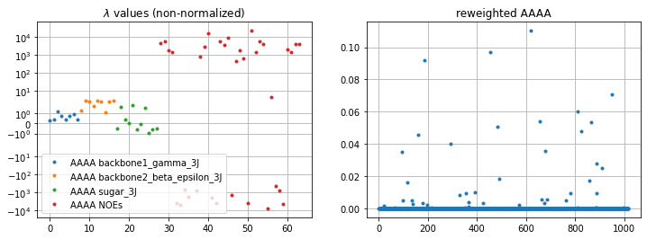

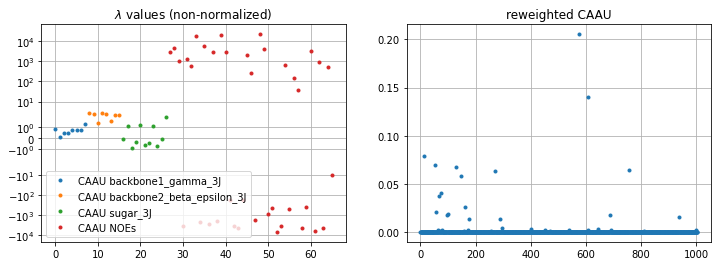

```python
for s in system_names:

    plt.figure(figsize = (12,4))

    plt.subplot(1,2,1)

    l = 0
    for i2,s2 in enumerate(Result.min_lambdas[s].keys()):
        l_new = l+len(Result.min_lambdas[s][s2])
        plt.plot(np.arange(l,l_new),Result.min_lambdas[s][s2],'.',label='%s %s' % (s,s2))
        l = l_new

    plt.title('$\lambda$ values (non-normalized)')
    plt.legend()# loc='center left', bbox_to_anchor=(1, 0.5))
    plt.grid()
    plt.yscale('symlog')

    plt.subplot(1,2,2)

    plt.plot(Result.weights_new[s],'.')
    plt.title('reweighted %s' % s)
    plt.grid()

    n_eff = np.exp(-Result.D_KL_alpha[s])

    print('system %s:' % s)
    print('effective n. of frames (on the total n.): ', n_eff)
    print('logZ: ', Result.logZ_new[s])
```

- finally, let's look at the average values of the observables in the new ensembles **av_g** and associated **chi2**; compare with experimental values gexp and with average values of the original ensembles.

```
chi2:  17.464389378171056
observables (first names in list):
 [["A1-H1'" 'A1-H8']
 ["A1-H1'" 'A2-H8']
 ['A1-H2' "A2-H1'"]
 ["A1-1H2'" 'A1-H8']
 ["A1-1H2'" "A2-H1'"]]
```

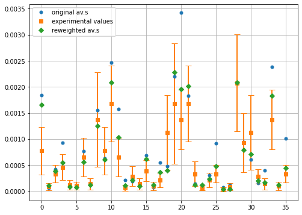

```python
s1 = 'AAAA'
s2 = 'NOEs'

print('chi2: ',Result.chi2[s1][s2])
print('observables (first names in list):\n',data.mol[s1].names[s2][:5])

plt.figure(figsize=(8,6))

# compute average values with original ensemble
g_mean = np.matmul(data.mol[s1].weights, data.mol[s1].g[s2])

plt.plot(g_mean,'.',label='original av.s',markersize=10)

plt.plot(data.mol[s1].gexp[s2][:,0],'s',label='experimental values')
plt.errorbar(np.arange(len(data.mol[s1].gexp[s2][:,0])), data.mol[s1].gexp[s2][:,0], data.mol[s1].gexp[s2][:,1], fmt = ' ',
    color = 'tab:orange', capsize = 5, lw = 2)

plt.plot(Result.av_g[s1][s2], 'D', label = 'reweighted av.s')

plt.legend()
plt.grid()
```

### c. Determine optimal hyper parameter $\alpha$ through cross validation (scan over $\alpha$)

The loss function for Ensemble Refinement, previously introduced, has one hyper-parameter $\alpha$ which needs to be fixed. This hyper-parameter tunes the reliability given to the original ensemble in spite of the trust to experimental data.

Suitable values of $\alpha$ can be determined through cross validation procedure: randomly split the full data set into training and test set, then select the value of $\alpha$ which minimizes the $\chi^2$ on the test set (either same observables as in training but new frames or new observables).

Let's perform just one splitting into training/test set (as an example) and scan over different values of $\alpha$ (in logarithmic scale).

The function **select_traintest** can be used to get **data_train** and **data_test** by simply passing a **random_state** (a random integer), which randomly selects **test_obs** and **test_frames**.

```python
data_train, data_test, test_obs, test_frames = select_traintest(data, random_state=1)
```

```
Input random_state employed both for test_obs and test_frames
```

```python
vars(data.mol['AAAA']).keys()
```

```
dict_keys(['temperature', 'gexp', 'names', 'ref', 'g', 'forward_model', 'forward_qs', 'weights', 'n_experiments', 'n_frames'])
```

```python
n_uNOEs = 0

for name in data.properties.system_names:
    n_uNOEs += data.mol[name].n_experiments['uNOEs']

n_uNOEs
```

```
2016
```

```python
n_tot_exp = data.properties.tot_n_experiments(data)
n_test_exp = len(unwrap_dict(test_obs))

n_train_exp = n_tot_exp - n_test_exp

print(n_tot_exp, n_test_exp, n_train_exp)
```

```
2384 478 1906
```

```python
print('test observables:\n', test_obs)
print('test frames:\n', test_frames)
```

[output not shown]

[output cut: 133 more lines]

Default values for the fraction of test observables and frames are $20\%$ for both (you can change this ratio by selecting **test_frames_size** and/or **test_obs_size** as input variables). By default, test observables are evaluated only on test frames; you can also consider both on training and test frames, by setting **if_all_frames** = True.

```python
data_train, data_test, test_obs, test_frames = select_traintest(data, test_frames_size = 0.2, test_obs_size = 0.3,
    random_state = 4, if_all_frames = True)
```

```
Input random_state employed both for test_obs and test_frames
```

[output not shown]

Alternatively, we can also directly pass test_obs and test_frames.

```python
out = select_traintest(data, test_obs = test_obs, test_frames = test_frames)

data_train = out[0]
data_test = out[1]
```

Now, let's scan over different values of $\alpha$ for a given partition of the full data set into training and test set. Let's work directly with logarithms in base 10, to explore several orders of magnitude for $\alpha$.

We can also pass data_test as input to minimizer: after the minimization of the loss function on data_train, we evaluate corresponding properties (such as $D_{KL}$, $\chi^2$, loss function) on test frames and $\chi^2$ on test observables.

```python
log10_alphas = np.arange(-2, 7, 1)

Results = {}

for log10_alpha in log10_alphas:
    print(log10_alpha)

    alpha = 10**np.float64(log10_alpha)
    Results[log10_alpha] = minimizer(data_train, alpha=alpha, data_test=data_test)

    clear_output()
```

```python
vars(Results[log10_alpha]).keys()
```

```
dict_keys(['loss', 'min_lambdas', 'minis', 'time', 'D_KL_alpha', 'abs_difference', 'av_g', 'chi2', 'logZ_new', 'weights_new', 'loss_test', 'D_KL_alpha_test', 'abs_difference_test', 'av_g_test', 'chi2_test', 'logZ_new_test', 'weights_new_test', 'avg_new_obs', 'chi2_new_obs'])
```

For each value of the hyper-parameter, we now have corresponding quantities for test frames (such as **loss_test**, **D_KL_alpha_test**, **av_g_test**, **chi2_test**, **weights_new_test**) and for test observables (**avg_new_obs** and **chi2_new_obs**).

Let's compare the loss function for training set and test set (new frames):

- at high values of $\alpha$, the two values almost overlap;
- decreasing $\alpha$, both the two loss functions decrease, except that the one on the test at a certain point starts to increase marking overfitting.

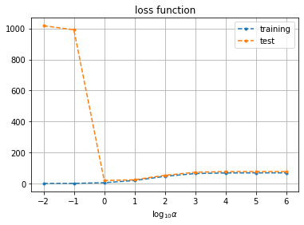

```python
loss = [Results[log10_alpha].loss for log10_alpha in log10_alphas]
loss_test = [Results[log10_alpha].loss_test for log10_alpha in log10_alphas]

plt.title('loss function')
plt.plot(log10_alphas, loss, '.--', label = 'training')
plt.plot(log10_alphas, loss_test, '.--', label = 'test')
plt.xlabel(r'$\log_{10}\alpha$')
plt.legend()
plt.grid()
```

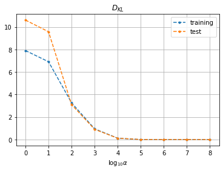

```python
D_KL_train = [np.sum(unwrap_dict(Results[log10_alpha].D_KL_alpha)) for log10_alpha in log10_alphas]
D_KL_test = [np.sum(unwrap_dict(Results[log10_alpha].D_KL_alpha_test)) for log10_alpha in log10_alphas]

plt.title('$D_{KL}$')
plt.plot(D_KL_train, '.--', label = 'training')
plt.plot(D_KL_test, '.--', label = 'test')
plt.xlabel(r'$\log_{10}\alpha$')
plt.legend()
plt.grid()
```

Now, the $\chi^2$, including also test observables

```python
chi2s = [np.sum(unwrap_dict(Results[log10_alpha].chi2)) for log10_alpha in log10_alphas]
n_obs_train = data_train.properties.tot_n_experiments(data_train)

red_chi2s = np.array(chi2s)/n_obs_train

chi2s_test1 = [np.sum(unwrap_dict(Results[log10_alpha].chi2_test)) for log10_alpha in log10_alphas] # .chi2_test
red_chi2s_test1 = np.array(chi2s_test1)/n_obs_train

chi2s_test2 = [np.sum(unwrap_dict(Results[log10_alpha].chi2_new_obs)) for log10_alpha in log10_alphas] # .chi2_test
n_obs_test = len(unwrap_dict(test_obs))

red_chi2s_test2 = np.array(chi2s_test2)/n_obs_test
```

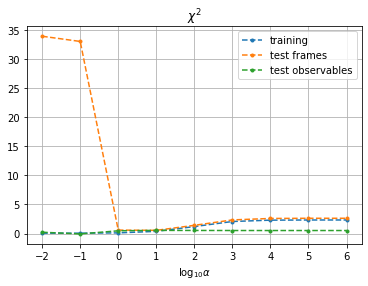

```python
plt.plot(log10_alphas, red_chi2s, '.--', label = 'training')
plt.plot(log10_alphas, red_chi2s_test1, '.--', label = 'test frames')
plt.plot(log10_alphas, red_chi2s_test2, '.--', label = 'test observables')

plt.legend()
plt.title('$\chi^2$')
plt.xlabel(r'$\log_{10}\alpha$')
plt.grid()
```

### d. Determine optimal hyper parameter $\alpha$ through cross validation (automatic optimization)

Rather than performing a scan over the hyper-parameter $\alpha$, we now minimize the $\chi^2$ on the test set (computed at optimal parameters obtained in training) with respect to $\alpha$.

```python
starting_alpha = 1e2
```

by default, which_set = 'validation' (rather than 'test' or 'training'), namely evaluate $\chi^2$ on same observables as training but new frames of the trajectory

```python
mini = hyper_minimizer(data, starting_alpha = starting_alpha, random_states = 2, which_set = 'validation', gtol = 0.5)
```

```
Input random_state employed both for test_obs and test_frames
Input random_state employed both for test_obs and test_frames
log10 hyperpars:  [DeviceArray(2., dtype=float64)] ['alpha']
tot chi2:  179.99748935099893
tot gradient:  [164.58212585]
log10 hyperpars:  [2.] ['alpha']
tot chi2:  179.99748935099893
tot gradient:  [164.58212585]
log10 hyperpars:  [0.99] ['alpha']
tot chi2:  425.00547800983844
tot gradient:  [-1826.18114941]
log10 hyperpars:  [1.6329151] ['alpha']
tot chi2:  126.70090220074779
tot gradient:  [103.53961778]
log10 hyperpars:  [1.01026981] ['alpha']
tot chi2:  390.70284260061294
tot gradient:  [-1677.36149732]
log10 hyperpars:  [1.50044572] ['alpha']
tot chi2:  117.71717904095316
tot gradient:  [21.76320493]
log10 hyperpars:  [1.46519156] ['alpha']
tot chi2:  117.56919878055263
tot gradient:  [-12.86928899]
log10 hyperpars:  [1.47829186] ['alpha']
tot chi2:  117.4288039078597
tot gradient:  [1.38731611]
log10 hyperpars:  [1.47701706] ['alpha']
tot chi2:  117.45250335217828
tot gradient:  [-0.28903419]
log10 hyperpars:  [1.4782765] ['alpha']
tot chi2:  117.42846317524896
tot gradient:  [1.37390444]
log10 hyperpars:  [1.47827633] ['alpha']
tot chi2:  117.42845942991592
tot gradient:  [1.37375855]
log10 hyperpars:  [1.47764669] ['alpha']
tot chi2:  117.4146600480089
tot gradient:  [0.85890873]
log10 hyperpars:  [1.47659801] ['alpha']
tot chi2:  117.4074816543556
tot gradient:  [-0.31450289]
```

```python
mini
```

```
      fun: 117.4074816543556
 hess_inv: array([[0.00122096]])
      jac: array([-0.31450289])
  message: 'Optimization terminated successfully.'
     nfev: 12
      nit: 6
     njev: 12
   status: 0
  success: True
        x: array([1.47659801])
```

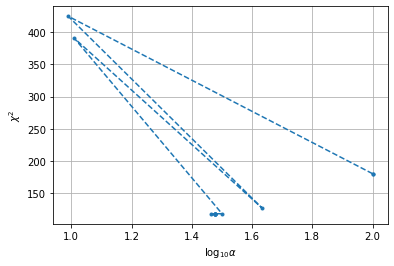

```python
x = mini['intermediate'].log10_hyperpars
y = mini['intermediate'].av_chi2

plt.plot(x,y,'.--')
plt.xlabel(r'$\log_{10}\alpha$')
plt.ylabel('$\chi^2$')
plt.grid()
```

```python
optimal_alpha = 10**(mini.x)
```

```python
data = load_data(infos)
```

```
loading data from directory...
loading  AAAA
loading  CAAU
done
```

```python
Result = minimizer(data, alpha = optimal_alpha)
```

```python
vars(Result)
```

```
{'loss': DeviceArray([40.16542256], dtype=float64),
 'min_lambdas': {'AAAA': {'NOEs': DeviceArray([ 150.73992103,  -67.29285849,  105.62119535,  118.96876618,
                 -74.04540148, -102.87904109,   37.76755821,  -23.09866382,
                  10.40497866,  -30.11556459,   47.2407546 ,   97.55062434,
                1033.66361603,  -76.13445458, -119.69251423,  182.8412221 ,
                 -41.69269727,  349.17365518,  -39.84692591,   15.85069759,
                  91.86738887,   23.85272636,  -97.62859541,  614.99665463,
                 154.34680669,  303.89155513,  402.68529294,  191.27067489,
                  -1.15469979,  -20.86065066,  -19.20484019, -155.03477145,
                 169.41074214,   62.59969065,  106.82633384,  347.63227384],            dtype=float64)},
  'CAAU': {'NOEs': DeviceArray([ 116.99604616,   28.40984552,   54.57910406, -160.33853852,
                   7.83028943,   63.83780474,  502.50050988,  -83.25424726,
                 -11.50902254, -123.38260704,  135.89938945,    2.12502521,
                 595.11278806,  419.63838571,   43.21470051,  -99.94908489,
                -185.66864586,   14.28015308,   44.53595355,   29.13265554,
                 -19.60196942,  675.61805078,  168.1945468 ,  -81.70109531,
                 -15.01124509, -193.18181435, -114.6581109 ,  -39.24461509,
                 -25.90665384,   -6.54059906,  -14.92124284,  -90.26485774,
                 -16.43570085,  100.58325451, -159.15313706,    6.0811717 ,
                 -63.53260822,  -59.03742151,   30.93131767], dtype=float64)}},
 'minis': {'AAAA':       fun: -0.7540170200156602
   hess_inv: array([[ 9.65977371e-01,  3.41969151e-03,  1.15405570e-02, ...,
           4.91140967e-03,  3.99700499e-03,  3.19063022e-02],
         [ 3.41969151e-03,  2.39299615e-01, -2.71638128e-02, ...,
           1.46149220e-02,  1.11411649e-03,  1.59682152e-02],
         [ 1.15405570e-02, -2.71638128e-02,  1.02543300e+00, ...,
           9.21195591e-03, -3.08241246e-03,  1.36736729e-02],
         ...,
         [ 4.91140967e-03,  1.46149220e-02,  9.21195591e-03, ...,
           1.02149860e+00,  8.84178381e-03,  5.88241274e-02],
         [ 3.99700499e-03,  1.11411649e-03, -3.08241246e-03, ...,
           8.84178381e-03,  6.34131504e-02,  1.35745843e-02],
         [ 3.19063022e-02,  1.59682152e-02,  1.36736729e-02, ...,
           5.88241274e-02,  1.35745843e-02,  1.27940286e+00]])
        jac: array([-2.09407588e-04,  6.80579830e-05,  3.61852141e-05, -8.27944185e-07,
          2.70374008e-05,  6.36518951e-06,  3.69958470e-05,  2.02661377e-04,
          1.99784004e-04, -3.56322165e-04,  4.17092967e-04, -2.06739859e-05,
         -6.23802708e-06,  1.85189667e-04,  7.72879994e-05, -1.67252512e-04,
         -1.13493420e-04,  4.55458450e-07, -1.02660865e-06,  1.39301039e-04,
         -1.31709359e-04, -4.81741813e-05,  1.58799683e-04, -1.35743258e-04,
```

[output cut: 80 more lines]

```
                1.80827322e-03, 3.85364788e-03, 1.31259446e-04,
                9.55364530e-05, 5.94567106e-04, 1.00584384e-04,
                7.86114959e-04, 5.13221092e-05, 5.93833128e-05,
                4.87634794e-04, 1.11783168e-03, 2.29535666e-03,
                1.22575728e-03, 1.83537622e-04, 8.76079863e-04,
                1.33783613e-04, 5.77159747e-05, 2.91058312e-04,
                1.28357145e-04, 6.23324149e-05, 5.15058036e-04],            dtype=float64)}},
 'chi2': {'AAAA': {'NOEs': DeviceArray(28.09338913, dtype=float64)},
  'CAAU': {'NOEs': DeviceArray(21.70523108, dtype=float64)}},
 'logZ_new': {'AAAA': DeviceArray(-2.18429709, dtype=float64),
  'CAAU': DeviceArray(-1.26236657, dtype=float64)},
 'weights_new': {'AAAA': DeviceArray([1.54947721e-06, 1.15003775e-06, 9.24145228e-07, ...,
               2.73630288e-06, 2.21980488e-06, 6.72827182e-07],            dtype=float64),
  'CAAU': DeviceArray([3.44748291e-07, 8.23605258e-07, 1.83757768e-06, ...,
               5.07711387e-07, 7.35881437e-07, 1.28982623e-06],            dtype=float64)}}
```

Look at section b) for analysis of Result.

### do all together

```python
Result = MDRefinement(infos, stride = stride, starting_alpha = 1e2, random_states = 2, which_set = 'validation', gtol = 0.5)
```

```
loading data from directory...
loading  AAAA
loading  CAAU
done

search for optimal hyperparameters ...
Input random_state employed both for test_obs and test_frames
Input random_state employed both for test_obs and test_frames
log10 hyperpars:  [DeviceArray(2., dtype=float64)] ['alpha']
tot chi2:  179.99748935099893
tot gradient:  [164.58212585]
log10 hyperpars:  [2.] ['alpha']
tot chi2:  179.99748935099893
tot gradient:  [164.58212585]
log10 hyperpars:  [0.99] ['alpha']
tot chi2:  425.00547800983844
tot gradient:  [-1826.18114941]
log10 hyperpars:  [1.6329151] ['alpha']
tot chi2:  126.70090220074779
tot gradient:  [103.53961778]
log10 hyperpars:  [1.01026981] ['alpha']
tot chi2:  390.70284260061294
tot gradient:  [-1677.36149732]
log10 hyperpars:  [1.50044572] ['alpha']
tot chi2:  117.71717904095316
tot gradient:  [21.76320493]
log10 hyperpars:  [1.46519156] ['alpha']
tot chi2:  117.56919878055263
tot gradient:  [-12.86928899]
log10 hyperpars:  [1.47829186] ['alpha']
tot chi2:  117.4288039078597
tot gradient:  [1.38731611]
log10 hyperpars:  [1.47701706] ['alpha']
tot chi2:  117.45250335217828
tot gradient:  [-0.28903419]
log10 hyperpars:  [1.4782765] ['alpha']
tot chi2:  117.42846317524896
tot gradient:  [1.37390444]
log10 hyperpars:  [1.47827633] ['alpha']
tot chi2:  117.42845942991592
tot gradient:  [1.37375855]
log10 hyperpars:  [1.47764669] ['alpha']
tot chi2:  117.4146600480089
tot gradient:  [0.85890873]
log10 hyperpars:  [1.47659801] ['alpha']
tot chi2:  117.4074816543556
tot gradient:  [-0.31450289]

optimal hyperparameters: alpha: 29.963876982768817

refinement with optimal hyperparameters on the full data set
loading data from directory...
loading  AAAA
loading  CAAU
done
```

```python
vars(Result)
```

```
{'loss': DeviceArray(40.16542256, dtype=float64),
 'min_lambdas': {'AAAA': {'NOEs': DeviceArray([ 150.73992103,  -67.29285849,  105.62119535,  118.96876618,
                 -74.04540148, -102.87904109,   37.76755821,  -23.09866382,
                  10.40497866,  -30.11556459,   47.2407546 ,   97.55062434,
                1033.66361603,  -76.13445458, -119.69251423,  182.8412221 ,
                 -41.69269727,  349.17365518,  -39.84692591,   15.85069759,
                  91.86738887,   23.85272636,  -97.62859541,  614.99665463,
                 154.34680669,  303.89155513,  402.68529294,  191.27067489,
                  -1.15469979,  -20.86065066,  -19.20484019, -155.03477145,
                 169.41074214,   62.59969065,  106.82633384,  347.63227384],            dtype=float64)},
  'CAAU': {'NOEs': DeviceArray([ 116.99604616,   28.40984552,   54.57910406, -160.33853852,
                   7.83028943,   63.83780474,  502.50050988,  -83.25424726,
                 -11.50902254, -123.38260704,  135.89938945,    2.12502521,
                 595.11278806,  419.63838571,   43.21470051,  -99.94908489,
                -185.66864586,   14.28015308,   44.53595355,   29.13265554,
                 -19.60196942,  675.61805078,  168.1945468 ,  -81.70109531,
                 -15.01124509, -193.18181435, -114.6581109 ,  -39.24461509,
                 -25.90665384,   -6.54059906,  -14.92124284,  -90.26485774,
                 -16.43570085,  100.58325451, -159.15313706,    6.0811717 ,
                 -63.53260822,  -59.03742151,   30.93131767], dtype=float64)}},
 'minis': {'AAAA':       fun: -0.7540170200156602
   hess_inv: array([[ 9.65977371e-01,  3.41969151e-03,  1.15405570e-02, ...,
           4.91140967e-03,  3.99700499e-03,  3.19063022e-02],
         [ 3.41969151e-03,  2.39299615e-01, -2.71638128e-02, ...,
           1.46149220e-02,  1.11411649e-03,  1.59682152e-02],
         [ 1.15405570e-02, -2.71638128e-02,  1.02543300e+00, ...,
           9.21195591e-03, -3.08241246e-03,  1.36736729e-02],
         ...,
         [ 4.91140967e-03,  1.46149220e-02,  9.21195591e-03, ...,
           1.02149860e+00,  8.84178381e-03,  5.88241274e-02],
         [ 3.99700499e-03,  1.11411649e-03, -3.08241246e-03, ...,
           8.84178381e-03,  6.34131504e-02,  1.35745843e-02],
         [ 3.19063022e-02,  1.59682152e-02,  1.36736729e-02, ...,
           5.88241274e-02,  1.35745843e-02,  1.27940286e+00]])
        jac: array([-2.09407588e-04,  6.80579830e-05,  3.61852141e-05, -8.27944185e-07,
          2.70374008e-05,  6.36518951e-06,  3.69958470e-05,  2.02661377e-04,
          1.99784004e-04, -3.56322165e-04,  4.17092967e-04, -2.06739859e-05,
         -6.23802708e-06,  1.85189667e-04,  7.72879994e-05, -1.67252512e-04,
         -1.13493420e-04,  4.55458450e-07, -1.02660865e-06,  1.39301039e-04,
         -1.31709359e-04, -4.81741813e-05,  1.58799683e-04, -1.35743258e-04,
```

[output cut: 80 more lines]

```
                1.80827322e-03, 3.85364788e-03, 1.31259446e-04,
                9.55364530e-05, 5.94567106e-04, 1.00584384e-04,
                7.86114959e-04, 5.13221092e-05, 5.93833128e-05,
                4.87634794e-04, 1.11783168e-03, 2.29535666e-03,
                1.22575728e-03, 1.83537622e-04, 8.76079863e-04,
                1.33783613e-04, 5.77159747e-05, 2.91058312e-04,
                1.28357145e-04, 6.23324149e-05, 5.15058036e-04],            dtype=float64)}},
 'chi2': {'AAAA': {'NOEs': DeviceArray(28.09338913, dtype=float64)},
  'CAAU': {'NOEs': DeviceArray(21.70523108, dtype=float64)}},
 'logZ_new': {'AAAA': DeviceArray(-2.18429709, dtype=float64),
  'CAAU': DeviceArray(-1.26236657, dtype=float64)},
 'weights_new': {'AAAA': DeviceArray([1.54947721e-06, 1.15003775e-06, 9.24145228e-07, ...,
               2.73630288e-06, 2.21980488e-06, 6.72827182e-07],            dtype=float64),
  'CAAU': DeviceArray([3.44748291e-07, 8.23605258e-07, 1.83757768e-06, ...,
               5.07711387e-07, 7.35881437e-07, 1.28982623e-06],            dtype=float64)}}
```

## 2. Force-field refinement

### a. Load data

Load experimental data, observables and forward model as previously done.

Load also force-field correction terms and corresponding functional form.

```python
infos = {}

# Define global properties, valid for all the systems:
infos['global'] = {}
infos['global']['path_directory'] = '../../DATA'
infos['global']['system_names'] = ['AAAA','CCCC','GACC','UUUU','UCAAUC']

# Then, define properties which are specific of each system, like experimental data and observables
# If some properties are the same for all the systems, you can store them just once in infos['global']
infos['global']['g_exp'] = ['backbone1_gamma_3J', 'backbone2_beta_epsilon_3J', 'sugar_3J', 'NOEs', ('uNOEs','<')]
infos['global']['forward_qs'] = ['backbone1_gamma','backbone2_beta_epsilon','sugar']
infos['global']['obs'] = ['NOEs','uNOEs']
infos['global']['forward_coeffs'] = 'original_fm_coeffs'

# Select the stride for the frames
stride = 1000
```

```python
def forward_model_fun(fm_coeffs, forward_qs, selected_obs=None):

    # 1. compute the cosine (which is the quantity you need in the forward model;
    # you could do this just once before loading data)
    forward_qs_cos = {}

    for type_name in forward_qs.keys():
        forward_qs_cos[type_name] = np.cos(forward_qs[type_name])

    # if you have selected_obs, compute only the corresponding observables
    if selected_obs is not None:
        for type_name in forward_qs.keys():
            forward_qs_cos[type_name] = forward_qs_cos[type_name][:,selected_obs[type_name+'_3J']]

    # 2. compute observables (forward_qs_out) through forward model
    forward_qs_out = {
        'backbone1_gamma_3J': fm_coeffs[0]*forward_qs_cos['backbone1_gamma']**2 + fm_coeffs[1]*forward_qs_cos['backbone1_gamma'] + fm_coeffs[2],
        'backbone2_beta_epsilon_3J': fm_coeffs[3]*forward_qs_cos['backbone2_beta_epsilon']**2 + fm_coeffs[4]*forward_qs_cos['backbone2_beta_epsilon'] + fm_coeffs[5],
        'sugar_3J': fm_coeffs[6]*forward_qs_cos['sugar']**2 + fm_coeffs[7]*forward_qs_cos['sugar'] + fm_coeffs[8] }

    return forward_qs_out
```

same forward-model function for each system, so put it in infos['global']

```python
infos['global']['forward_model'] = forward_model_fun
```

Now, the force-field correction terms: we selected (for each molecule) \begin{equation} \beta\Delta V = \sum_{i}\Bigl[\phi_1\cos\alpha_i + \phi_2\sin\alpha_i + \phi_3 \cos \zeta_i + \phi_4 \sin\zeta_i\Bigr] \end{equation} where the sum is over residues. Since numpy arrays ff_terms have columns

['sinalpha[0]', 'sinalpha[1]', 'sinalpha[2]', 'sinzeta[0]', 'sinzeta[1]', 'sinzeta[2]', 'cosalpha[0]', 'cosalpha[1]', 'cosalpha[2]', 'coszeta[0]', 'coszeta[1]', 'coszeta[2]'],

such correction is defined by the following function (use jax.numpy).

```python
def ff_correction_tetramers(pars, f):
    out = jnp.matmul(pars, (f[:,[0,6]]+f[:,[1,7]]+f[:,[2,8]]).T)
    return out

def ff_correction_hexamers(pars, f):
    out = jnp.matmul(pars, (f[:,[0,10]]+f[:,[1,11]]+f[:,[2,12]]+f[:,[3,13]]+f[:,[4,14]]).T)
    return out
```

```python
infos['global']['ff_correction'] = ff_correction_tetramers
infos['UCAAUC'] = {'ff_correction': ff_correction_hexamers}

infos['global']['names_ff_pars'] = ['sin alpha', 'cos alpha']
```

```python
def ff_correction_tetramers(pars, f):
    out = jnp.matmul(pars, (f[:,[0,6,3,9]]+f[:,[1,7,4,10]]+f[:,[2,8,5,11]]).T)
    return out

def ff_correction_hexamers(pars, f):
    out = jnp.matmul(pars, (f[:,[0,10,5,15]]+f[:,[1,11,6,16]]+f[:,[2,12,7,17]]+f[:,[3,13,8,18]]+f[:,[4,14,9,19]]).T)
    return out
```

```python
infos['global']['ff_correction'] = ff_correction_tetramers
infos['UCAAUC'] = {'ff_correction': ff_correction_hexamers}

infos['global']['names_ff_pars'] = ['sin alpha', 'cos alpha', 'sin zeta', 'cos zeta']
```

```python
for name_sys in ['AAAA', 'CCCC', 'GACC', 'UUUU']: # except hexamers
    infos[name_sys] = {'n_temp_replica': 6}
```

```python
data = load_data(infos, stride=stride)
```

```
WARNING:absl:No GPU/TPU found, falling back to CPU. (Set TF_CPP_MIN_LOG_LEVEL=0 and rerun for more info.)
```

```
loading data from directory...
loading  AAAA
loading  CCCC
loading  GACC
loading  UUUU
loading  UCAAUC
done
```

Now, define the regularization for the force-field refinement. We can choose among 'plain l2' (acting on the coefficients) or 'KL divergence' (acting directly on the ensemble).

```python
regularization = {'force_field_reg': 'KL divergence'}
```

### b. Minimize the loss function and analyse the results

for a single choice of the hyper-parameter $\beta$

```python
# use function minimizer with selected data and alpha as input
Result = minimizer(data, regularization=regularization, beta=100)
```

```python
vars(Result).keys()
```

```
dict_keys(['loss', 'pars', 'mini', 'intermediates', 'time', 'reg_ff', 'av_g', 'chi2', 'weights_new', 'logZ_new'])
```

Besides quantities described in the previous section (such as: **av_g**, **chi2**, **weights_new**, **logZ_new**), we now have:

- output of minimization **mini**;
- optimal force-field correction parameters **pars**;
- value of force-field regularization **reg_ff**.

```python
Result.pars
```

[output not shown]

```python
Result.mini
```

```
      fun: 285.0834500891217
 hess_inv: array([[ 5.20491478e-02, -8.89295688e-02, -5.00415048e-02,
        -2.23536762e-03],
       [-8.89295688e-02,  1.12747644e+00,  1.16060221e-01,
        -1.68801647e-02],
       [-5.00415048e-02,  1.16060221e-01,  5.61942163e-02,
         7.66569900e-04],
       [-2.23536762e-03, -1.68801647e-02,  7.66569900e-04,
         2.57011281e-02]])
      jac: array([-4.58613412e-05, -3.04716135e-06, -7.24710956e-05, -5.68219475e-05])
  message: 'Optimization terminated successfully.'
     nfev: 36
      nit: 26
     njev: 36
   status: 0
  success: True
        x: array([ 0.46316927, -3.50501963, -0.31937378,  1.15776919])
```

```python
Result.reg_ff
```

[output not shown]

### c. Determine optimal hyper parameter $\beta$ through cross validation (scan over $\beta$)

```python
data_train, data_test, test_obs, test_frames = select_traintest(data, test_frames_size=0.3, test_obs_size=0.3, random_state=2, replica_infos=infos)
```

```
Input random_state employed both for test_obs and test_frames
```

```python
log10_betas = np.arange(-2, 7, 0.5)

Results = {}

for log10_beta in log10_betas:
    print(log10_beta)

    beta = 10**np.float64(log10_beta)
    Results[log10_beta] = minimizer(data_train, regularization=regularization, beta=beta, data_test=data_test)

    print(Results[log10_beta].loss)

    clear_output()
```

```python
log10_betas = np.arange(-2, 7, 0.5)

Results = {}

for log10_beta in log10_betas:
    print(log10_beta)

    beta = 10**np.float64(log10_beta)
    Results[log10_beta] = minimizer(data_train, regularization=regularization, beta=beta, data_test=data_test)

    print(Results[log10_beta].loss)

    clear_output()
```

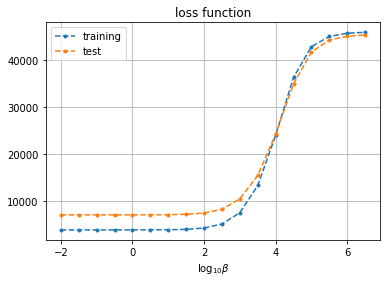

```python
loss = [Results[log10_beta].loss for log10_beta in log10_betas]
loss_test = [Results[log10_beta].loss_test for log10_beta in log10_betas]

plt.title('loss function')
plt.plot(log10_betas, loss, '.--', label = 'training')
plt.plot(log10_betas, loss_test, '.--', label = 'test')
plt.xlabel(r'$\log_{10}\beta$')
plt.legend()
plt.grid()
```

```python
infos['global']['names_ff_pars']
```

[output not shown]

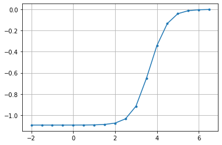

```python
coeffs = [Results[log10_beta].pars[1] for log10_beta in log10_betas]

plt.plot(log10_betas, coeffs, '.-')
plt.grid()
```

```python
chi2s = [np.sum(unwrap_dict(Results[log10_beta].chi2)) for log10_beta in log10_betas]
n_obs_train = data_train.properties.tot_n_experiments(data_train)

red_chi2s = np.array(chi2s)/n_obs_train

chi2s_test1 = [np.sum(unwrap_dict(Results[log10_beta].chi2_test)) for log10_beta in log10_betas] # .chi2_test
red_chi2s_test1 = np.array(chi2s_test1)/n_obs_train

chi2s_test2 = [np.sum(unwrap_dict(Results[log10_beta].chi2_new_obs)) for log10_beta in log10_betas] # .chi2_test
n_obs_test = len(unwrap_dict(test_obs))

red_chi2s_test2 = np.array(chi2s_test2)/n_obs_test
```

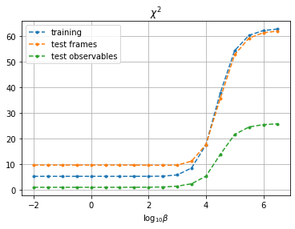

```python
plt.plot(log10_betas, red_chi2s, '.--', label = 'training')
plt.plot(log10_betas, red_chi2s_test1, '.--', label = 'test frames')
plt.plot(log10_betas, red_chi2s_test2, '.--', label = 'test observables')

plt.legend()
plt.title('$\chi^2$')
plt.xlabel(r'$\log_{10}\beta$')
plt.grid()
```

```python
print([Results[log10_beta].mini.success for log10_beta in log10_betas])
```

```
[True, True, True, True, True, True, True, True, True, True, True, True, True, True, True, True, True, True]
```

```python
starting_pars = Results[0.5].pars
```

```python
log10_betas = np.arange(-2, 7, 0.5)

Results = {}

for log10_beta in log10_betas:
    print(log10_beta)

    beta = 10**np.float64(log10_beta)
    Results[log10_beta] = minimizer(data_train, regularization = regularization, beta = beta, data_test = data_test, starting_pars = starting_pars)

    print(Results[log10_beta].loss)

    clear_output()
```

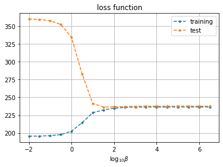

```python
loss = [Results[log10_beta].loss for log10_beta in log10_betas]
loss_test = [Results[log10_beta].loss_test for log10_beta in log10_betas]

plt.title('loss function')
plt.plot(log10_betas, loss, '.--', label = 'training')
plt.plot(log10_betas, loss_test, '.--', label = 'test')
plt.xlabel(r'$\log_{10}\beta$')
plt.legend()
plt.grid()
```

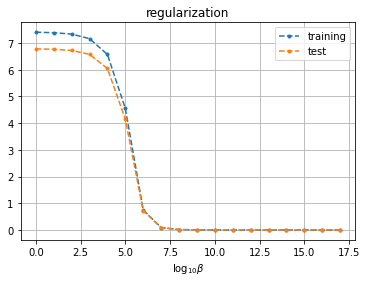

```python
D_KL_train = [np.sum(unwrap_dict(Results[log10_beta].reg_ff)) for log10_beta in log10_betas]
D_KL_test = [np.sum(unwrap_dict(Results[log10_beta].reg_ff_test)) for log10_beta in log10_betas]

plt.title('regularization')
plt.plot(D_KL_train, '.--', label = 'training')
plt.plot(D_KL_test, '.--', label = 'test')
plt.xlabel(r'$\log_{10}\beta$')
plt.legend()
plt.grid()
```

```python
chi2s = [np.sum(unwrap_dict(Results[log10_beta].chi2)) for log10_beta in log10_betas]
n_obs_train = data_train['global'].tot_n_experiments(data_train)

red_chi2s = np.array(chi2s)/n_obs_train

chi2s_test1 = [np.sum(unwrap_dict(Results[log10_beta].chi2_test)) for log10_beta in log10_betas] # .chi2_test
red_chi2s_test1 = np.array(chi2s_test1)/n_obs_train

chi2s_test2 = [np.sum(unwrap_dict(Results[log10_beta].chi2_new_obs)) for log10_beta in log10_betas] # .chi2_test
n_obs_test = len(unwrap_dict(test_obs))

red_chi2s_test2 = np.array(chi2s_test2)/n_obs_test
```

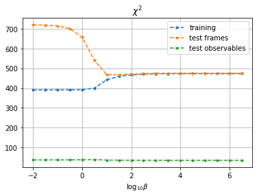

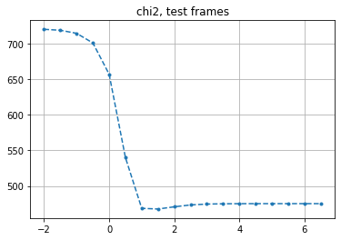

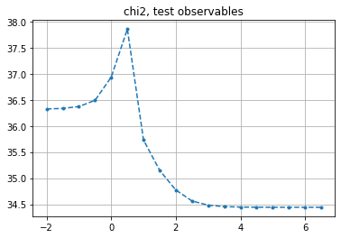

```python
plt.plot(log10_betas, chi2s, '.--', label = 'training')
plt.plot(log10_betas, chi2s_test1, '.--', label = 'test frames')
plt.plot(log10_betas, chi2s_test2, '.--', label = 'test observables')

plt.legend()
plt.title('$\chi^2$')
plt.xlabel(r'$\log_{10}\beta$')
plt.grid()

plt.figure()
plt.plot(log10_betas, chi2s_test1, '.--', label = 'test frames')
plt.title('chi2, test frames')
plt.grid()

plt.figure()
plt.plot(log10_betas, chi2s_test2, '.--', label = 'test observables')
plt.title('chi2, test observables')
plt.grid()
```

### d. Determine optimal hyper parameter $\beta$ through cross validation (automatic optimization)

Let's take the same random_state used for the scan. Here **random_states** can be a list of values or an integer; if it is an integer, you will take values in np.arange(random_states).

```python
starting_beta = 1

mini = hyper_minimizer(data, regularization = regularization, starting_beta = starting_beta, random_states = [2], starting_pars = starting_pars)
```

```
Input random_state employed both for test_obs and test_frames
log10 hyperpars:  [DeviceArray(0., dtype=float64)] ['beta']
tot chi2:  657.0989509863348
tot gradient:  [-152.45869821]
log10 hyperpars:  [0.] ['beta']
tot chi2:  657.0989509863348
tot gradient:  [-152.45869821]
log10 hyperpars:  [1.01] ['beta']
tot chi2:  468.3693258698372
tot gradient:  [-22.5461002]
log10 hyperpars:  [1.1852837] ['beta']
tot chi2:  467.07360566704546
tot gradient:  [-1.34951948]
log10 hyperpars:  [1.19644346] ['beta']
tot chi2:  467.0602418806326
tot gradient:  [-1.0524543]
log10 hyperpars:  [1.22209289] ['beta']
tot chi2:  467.0413456162542
tot gradient:  [-0.42517636]
```

```python
mini
```

```
      fun: 467.0413456162542
 hess_inv: array([[0.03756671]])
      jac: array([-0.42517636])
  message: 'Optimization terminated successfully.'
     nfev: 5
      nit: 4
     njev: 5
   status: 0
  success: True
        x: array([1.22209289])
```

```python
starting_beta = 10**mini.x

mini2 = hyper_minimizer(data, regularization = regularization, starting_beta = starting_beta, random_states = [2], which_set = 'test', starting_pars = starting_pars)
```

```
Input random_state employed both for test_obs and test_frames
```

```
log10 hyperpars:  [1.22209289] ['beta']
New evaluation:
loss:  275.9155436501145
gradient:  [ 15.35127511  -9.04572861 -17.39103002  15.82186062]

New evaluation:
loss:  271.2288368007547
gradient:  [ 21.55634479 -15.11850864  34.20302808 -18.6338733 ]

New evaluation:
loss:  272.357448770612
gradient:  [-48.31790364 -15.3158465  -31.55294149 -12.06668938]

New evaluation:
loss:  268.69454038601975
gradient:  [ -3.94195706 -15.14120574   9.81590609 -15.85437518]

New evaluation:
loss:  263.73416077611796
gradient:  [ -4.41017571 -14.61961542   8.9840051  -12.96736957]

New evaluation:
loss:  248.01464402792865
gradient:  [ -3.9952376  -11.95298115   9.40247393   1.81615909]

New evaluation:
loss:  238.2293291226762
gradient:  [-13.22534213  19.0581175  -13.64305686   0.45961333]

New evaluation:
loss:  235.62816325607469
gradient:  [-6.78958971 -7.20917815 -1.98527689 -3.62422861]

New evaluation:
loss:  275.5164990990347
gradient:  [10.03510966 66.90537498 40.36704847 16.23575624]

New evaluation:
loss:  231.57848327323566
gradient:  [-3.79228944 -3.23543197 -0.70305717  1.17248496]
```

[output cut: 229 more lines]

```

New evaluation:
loss:  229.9731385619217
gradient:  [-0.00710246  0.00139338 -0.00599077 -0.00295951]

New evaluation:
loss:  229.97313798185468
gradient:  [ 0.00195554 -0.00086742  0.00208566  0.0001687 ]

New evaluation:
loss:  229.97313793086028
gradient:  [1.58648076e-04 6.65566119e-05 2.14149405e-04 1.07626443e-04]

tot chi2:  132.21272885005425
tot gradient:  [0.27195238]
```

```python
mini2
```

```
      fun: 132.21272885005425
 hess_inv: array([[0.04261599]])
      jac: array([0.27195238])
  message: 'Optimization terminated successfully.'
     nfev: 4
      nit: 2
     njev: 4
   status: 0
  success: True
        x: array([1.15049021])
```

#### multiple seeds

in order to get more robust results and avoid local minima

Let's use 2 random_states [0, 1]

```python
starting_beta = 1

mini = hyper_minimizer(data, regularization = regularization, starting_beta = starting_beta, random_states = 2)
```

```
Input random_state employed both for test_obs and test_frames
Input random_state employed both for test_obs and test_frames
log10 hyperpars:  [0.] ['beta']
New evaluation:
loss:  232.03396939608317
gradient:  [-71.76903903  -5.50396973 -51.47297004 -14.96441254]

New evaluation:
loss:  209.3237551897244
gradient:  [ 1.91964428 -0.2070328   7.12258622 -4.61135859]

New evaluation:
loss:  754.3009782677531
gradient:  [100.18299117 -38.11978997   8.27176677  55.42594161]

New evaluation:
loss:  208.56882815017454
gradient:  [ 1.89118245  0.90379216  7.67540293 -2.55457306]

New evaluation:
loss:  207.06287927808435
gradient:  [ 2.38351279  0.41791025  8.34649019 -1.6563974 ]

New evaluation:
loss:  207.134978140154
gradient:  [  2.76218824   7.17962407 -18.06578377   9.25915916]

New evaluation:
loss:  204.56412161010527
gradient:  [2.56130963 1.60978088 4.60399415 2.2174964 ]

New evaluation:
loss:  209.0164700744682
gradient:  [  3.32259559  10.61258435 -29.4412328   10.7129315 ]

New evaluation:
loss:  204.43707777237316
gradient:  [2.49418338 2.24616279 2.27085198 2.88819471]

New evaluation:
```

[output cut: 1187 more lines]

```

New evaluation:
loss:  208.00413699300728
gradient:  [ 0.0135647  -0.01458267  0.0441525  -0.05192956]

New evaluation:
loss:  208.00407534688708
gradient:  [ 0.00185338 -0.00251095  0.00534223 -0.00327808]

New evaluation:
loss:  208.00407421912914
gradient:  [-0.00050894 -0.00012593 -0.0004843  -0.00018283]

tot chi2:  887.3288621393083
tot gradient:  [-0.38020489]
```

```python
mini
```

```
      fun: 887.3288621393083
 hess_inv: array([[0.02972008]])
      jac: array([-0.38020489])
  message: 'Optimization terminated successfully.'
     nfev: 8
      nit: 4
     njev: 8
   status: 0
  success: True
        x: array([0.4458335])
```

```python
log10_betas = np.arange(-2, 7, 0.5)
random_states = np.arange(2)

Results = {}

for random_state in random_states:

    Results[random_state] = {}

    data_train, data_test, test_obs, test_frames = select_traintest(data, random_state = random_state)

    for log10_beta in log10_betas:

        print(random_state, log10_beta)

        beta = 10**np.float64(log10_beta)
        Results[random_state][log10_beta] = minimizer(data_train, regularization = regularization, beta = beta, data_test = data_test)

        clear_output()
```

```python
chi2s = []
chi2s_test1 = []
chi2s_test2 = []

for random_state in random_states:

    chi2s.append([np.sum(unwrap_dict(Results[random_state][log10_beta].chi2)) for log10_beta in log10_betas])
    chi2s_test1.append([np.sum(unwrap_dict(Results[random_state][log10_beta].chi2_test)) for log10_beta in log10_betas]) # .chi2_test
    chi2s_test2.append([np.sum(unwrap_dict(Results[random_state][log10_beta].chi2_new_obs)) for log10_beta in log10_betas]) # .chi2_test
```

```python
np.sum(chi2s, axis = 0)
```

```
array([809.5228564 , 809.52341081, 809.52885058, 809.58025051,
       810.03572158, 814.556873  , 826.18925646, 846.9433294 ,
       875.85522829, 894.73193725, 902.54606228, 905.24866257,
       906.12830864, 906.40904183, 906.49807601, 906.52625701,
       906.53517122, 906.5379904 ])
```

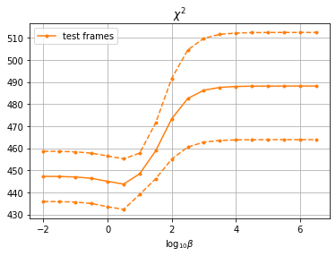

```python
# plt.plot(log10_betas, np.mean(chi2s, axis = 0), '.-', label = 'training', color = 'tab:blue')
plt.plot(log10_betas, np.mean(chi2s_test1, axis = 0), '.-', label = 'test frames', color = 'tab:orange')
# plt.plot(log10_betas, np.mean(chi2s_test2, axis = 0), '.-', label = 'test observables', color = 'tab:green')

for i in range(len(chi2s)):
    # plt.plot(log10_betas, chi2s[i], '.--', color = 'tab:blue')
    plt.plot(log10_betas, chi2s_test1[i], '.--', color = 'tab:orange')
    # plt.plot(log10_betas, chi2s_test2[i], '.--', color = 'tab:green')

plt.legend()
plt.title('$\chi^2$')
plt.xlabel(r'$\log_{10}\beta$')
plt.grid()
```

## 2b. Force-field refinement - alchemical calculations

Reproduce results from *Piomponi, Valerio, et al. "Molecular simulations matching denaturation experiments for N6-methyladenosine." ACS Central Science 8.8 (2022): 1218-1228.* https://pubs.acs.org/doi/full/10.1021/acscentsci.2c00565

### a. Load data

For alchemical calculations, we have both system_names (names of each molecular system) and cycle_names (names of the thermodynamic cycles); each cycle is composed by 4 systems; system_names with corresponding thermodynamic cycle must be defined as 'cycle_name' + '_' + s for s in ['AS','AD','MS','MD'] (A for adenosine, M for methylated; S for single, D for double strand). The experimental DG is between (AS, AD) and (MS, MD), the simulated one is between (AS, MS) and (AD, MD).

```python
infos = {}

infos['global'] = {}
infos['global']['temperature'] = 2.476
infos['global']['path_directory'] = '../../DATA_alchemical'

# names of the thermodynamic cyles and associated molecular systems, in the correct order

cycle_names = ['A1','A2','A3','A4','A5']  # ,'B1','B2','B3','B4','B5']

names = {}
for name in cycle_names:
    names[name] = []
    for string in ['AS','AD','MS','MD']:
        names[name].append((name + '_' + string))

infos['global']['cycle_names'] = names
infos['global']['system_names'] = [s2 for s in list(names.values()) for s2 in s]

# force-field correction terms

n_charges = 5

infos['global']['names_ff_pars'] = ['DQ %i' % (i+1) for i in range(n_charges)] + ['cos eta']

columns = []
for i in range(n_charges):
    columns.append('DQ %i' % (i+1))
    columns.append('DQ %i%i' % (i+1,i+1))
for i in range(n_charges):
    for j in range(i+1,n_charges):
        columns.append('DQ %i%i' % (i+1,j+1))
columns.append('cos eta')

# only methylated (M) systems have a force-field correction

for name in infos['global']['system_names']: infos[name] = {}

for name in infos['global']['cycle_names'].keys():
    for s in ['D','S']:
        infos[name + '_M' + s]['ff_terms'] = columns
```

define the force-field correction:

\begin{equation} \Delta U(x) = \sum_{i=1}^5 K_i(x) \Delta Q_i + \sum_{i=1}^5 \sum_{j=i}^5 K_{ij}(x) \Delta Q_i \Delta Q_j - V_\eta \cos\eta_6(x). \end{equation}

- use jax.numpy rather than numpy in order to do automatic differentiation
- phi is: ['DQ %i' for i in range(n_charges)] + ['cos eta']
- phi_vector is

['DQ 1', 'DQ 11', 'DQ 2', 'DQ 22', 'DQ 3', 'DQ 33', 'DQ 4', 'DQ 44', 'DQ 5', 'DQ 55', 'DQ 12', 'DQ 13', 'DQ 14', 'DQ 15', 'DQ 23', 'DQ 24', 'DQ 25', 'DQ 34', 'DQ 35', 'DQ 45', 'cos eta']

where 2 numbers (such as 'DQ 11' or 'DQ 23') mean the product 'DQ 1 * DQ 1' or 'DQ 2 * DQ 3'.

Legend: (Q1: N6; Q2: H61; Q3: N1; Q4: C10; Q5: H101/2/3)

```python
names_charges = ['N6', 'H61', 'N1', 'C10', 'H101/2/3']
```

```python
def ff_correction(phi, ff_terms):

    n_charges = 5

    phi_vector = []
    for i in range(n_charges):
        phi_vector.extend([phi[i], phi[i]**2])
    for i in range(n_charges):
        for j in range(i+1,n_charges):
            phi_vector.append(phi[i]*phi[j])
    phi_vector.append(-phi[-1])
    phi_vector = jnp.array(phi_vector)

    correction = jnp.matmul(ff_terms, phi_vector)

    return correction
```

```python
for k in infos['global']['system_names']:
    if k[-2] == 'M':
        infos[k]['ff_correction'] = ff_correction
```

```python
data = load_data(infos)
```

```
loading data from directory...
loading  A1_AS
```

```
WARNING:absl:No GPU/TPU found, falling back to CPU. (Set TF_CPP_MIN_LOG_LEVEL=0 and rerun for more info.)
```

```
loading  A1_AD
loading  A1_MS
loading  A1_MD
loading  A2_AS
loading  A2_AD
loading  A2_MS
loading  A2_MD
loading  A3_AS
loading  A3_AD
loading  A3_MS
loading  A3_MD
loading  A4_AS
loading  A4_AD
loading  A4_MS
loading  A4_MD
loading  A5_AS
loading  A5_AD
loading  A5_MS
loading  A5_MD
done
```

In order to avoid numerical issues, put to zero the force-field correction terms corresponding to zero original weights; you could also this in a different way, by selecting only frames with non-zero weights, but then you would have to take this into account when computing the relative entropy or the Kish sample size.

```python
for s in data.properties.system_names:
    # BE CAREFUL!!!
    # if you do this, then when you compute the relative entropy or Kish size,
    # you have to take into account how many zero frames there was

    # wh = np.argwhere(data.weights[s]!=0).flatten()

    # data.weights[s] = data.weights[s][wh]
    # if s in data.f.keys():
    #     data.f[s] = data.f[s].iloc[wh]

    # otherwise, you can put to zero the corresponding force-field correction terms

    if hasattr(data.mol[s], 'f'):
        wh = np.argwhere(data.mol[s].weights == 0).flatten()
        data.mol[s].f[wh] = 0
```

Valerio put uncertainties = 1

```python
for s in data.properties.cycle_names:
    data.cycle[s].gexp_DDG[1] = 1
```

### b. Minimize the loss function and analyse the results - scan over $\beta$

```python
from joblib import Parallel, delayed
```

#### L2 regularization

\begin{equation} \sum_{i=0}^4 \Delta Q_i^2 + \Delta Q_5^2 = \sum_{i=0}^4 \Delta Q_i^2 + \Bigl(\sum_{i=0}^4 \Delta Q_i + 2 \Delta Q_4\Bigr)^2. \end{equation}

No regularization is added on $V_\eta$ parameter.

```python
regularization = {'force_field_reg': 'constraint 2'}
```

It can also be defined by the user

```python
def my_ff_reg(pars):
    lossf_reg = jnp.sum(pars[:-1]**2) + (np.sum(pars[:-1]) + 2*pars[4])**2  # + pars[-1]**2
    return lossf_reg
```

```python
regularization = {'force_field_reg': my_ff_reg}
```

```python
betas = np.array([0.1, 0.5, 1, 2, 5, 10, 20, 50, 100, 200, 500, 1000, 10000, 100000])
```

```python
log10_betas = np.linspace(-1, 5, 50)
betas = 10**log10_betas

print(betas)
```

```
[1.00000000e-01 1.32571137e-01 1.75751062e-01 2.32995181e-01
 3.08884360e-01 4.09491506e-01 5.42867544e-01 7.19685673e-01
 9.54095476e-01 1.26485522e+00 1.67683294e+00 2.22299648e+00
 2.94705170e+00 3.90693994e+00 5.17947468e+00 6.86648845e+00
 9.10298178e+00 1.20679264e+01 1.59985872e+01 2.12095089e+01
 2.81176870e+01 3.72759372e+01 4.94171336e+01 6.55128557e+01
 8.68511374e+01 1.15139540e+02 1.52641797e+02 2.02358965e+02
 2.68269580e+02 3.55648031e+02 4.71486636e+02 6.25055193e+02
 8.28642773e+02 1.09854114e+03 1.45634848e+03 1.93069773e+03
 2.55954792e+03 3.39322177e+03 4.49843267e+03 5.96362332e+03
 7.90604321e+03 1.04811313e+04 1.38949549e+04 1.84206997e+04
 2.44205309e+04 3.23745754e+04 4.29193426e+04 5.68986603e+04
 7.54312006e+04 1.00000000e+05]
```

let's look firstly at original $\chi^2$

```python
res = minimizer(data, regularization=regularization, beta=np.inf)
```

```
all the hyperparameters are infinite
```

```python
res.chi2
```

```
{'A1': 21.06397979742576,
 'A2': 0.368626108813756,
 'A3': 12.38209101979724,
 'A4': 0.02181011054578029,
 'A5': 0.6429245282261995}
```

without parallelization

Results = {} for beta in betas: print('beta: ', beta) Results[beta] = minimizer(data, regularization=regularization, beta=beta) clear_output()

with parallelization (faster)

```python
Results_l2 = Parallel(n_jobs=3, verbose=1)(delayed(minimizer)(
        data, regularization=regularization, beta=beta) for beta in betas)
```

```
[Parallel(n_jobs=3)]: Using backend LokyBackend with 3 concurrent workers.
[Parallel(n_jobs=3)]: Done  44 tasks      | elapsed: 29.1min
[Parallel(n_jobs=3)]: Done  50 out of  50 | elapsed: 32.1min finished
```

```python
vars(Results_l2[0]).keys()
```

```
dict_keys(['loss', 'pars', 'mini', 'intermediates', 'time', 'reg_ff', 'av_g', 'chi2', 'weights_new', 'logZ_new'])
```

plot both the correction coefficients (charges and $V_\eta$) and the deviation from original ensemble (which can be measured by the Kish size, the relative entropy or the employed L2 regularization)

save figures and results in folders

!mkdir ../../Figures !mkdir ../../Results

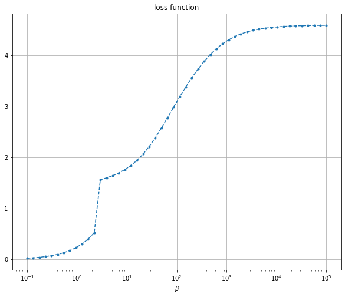

```python
loss = [Results_l2[i].loss for i in range(len(Results_l2))]

plt.figure(figsize=(10, 8))
plt.plot(betas, loss, '.--')
plt.xscale('log')
plt.title('loss function')
plt.xlabel(r'$\beta$')
plt.grid()
plt.show()

# plt.savefig('../../Figures/alchemical_L2_loss.png')
```

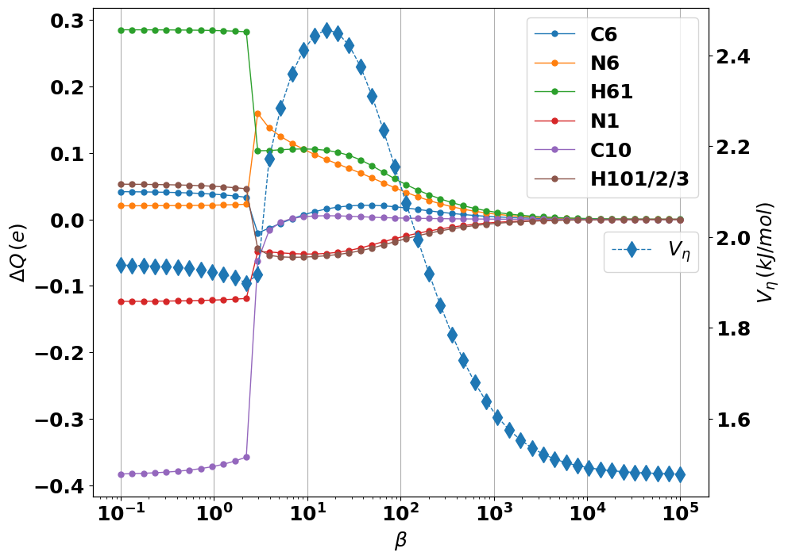

```python
font = {'weight' : 'bold', 'size' : 18}

matplotlib.rc('font', **font)
matplotlib.rcParams['lines.linewidth'] = 1
matplotlib.rcParams['lines.markersize'] = 10

fig, ax1 = plt.subplots(figsize=(10, 8))
ax2 = ax1.twinx()

# due to the constraint: total charge = 0
C6_charges = [(-np.sum(Results_l2[i].pars[:-1]) - 2*Results_l2[i].pars[-2]) for i in range(len(Results_l2))]
ax1.plot(betas, C6_charges, '.-', label='C6')

for j in range(len(names_charges)):
    ax1.plot(betas, [Results_l2[i].pars[j] for i in range(len(Results_l2))], '.-', label=names_charges[j])

ax2.plot(betas, [Results_l2[i].pars[-1] for i in range(len(Results_l2))], 'd--', label='$V_\eta$')

ax1.set_xscale('log')
ax1.set_xlabel(r'$\beta$')
ax1.grid(axis='x')

ax1.set_ylabel('$\Delta Q \, (e)$')
ax2.set_ylabel('$V_\eta \, (kJ/mol)$')

# ax1.set_ylim([-0.45, 0.35])
# ax2.set_ylim([1.4, 2.5])

ax1.legend()#loc='upper right')
ax2.legend(loc='center right')

# plt.title('$\Delta Q$ parameters')
# plt.xlabel('$\beta$')
# plt.legend()
# plt.grid()
plt.show()

# plt.savefig('../../Figures/alchemical_L2_parameters.png')
```

```python
vec = np.array([Results_l2[i].pars for i in range(len(Results_l2))])

df = pandas.DataFrame(vec[:,:-1], columns=[n + ' (e)' for n in names_charges])
df['C6 (e)'] = C6_charges
df[r'$V_\eta (kJ/mol)$'] = vec[:, -1]
df.index = betas

# df.to_csv('Results/alchemical_calculations/coefficients_L2charges')
```

Kish ratio: the ratio between Kish sizes of ensembles with original and optimized force field, respectively (for methylated systems)

```python
names = []

for name_sys in data.properties.system_names:
    if name_sys[-2] == 'M':
        names.append(name_sys)

kish_ratios = {}

for name_sys in names:
    kish_ratios[name_sys] = []
    for i in range(len(Results_l2)):
        ratio = np.sum(data.mol[name_sys].weights**2)/np.sum(Results_l2[i].weights_new[name_sys]**2)
        kish_ratios[name_sys].append(ratio)
```

```python
kish_ratios['average'] = []

for i in range(len(Results_l2)):
    kish_ratios['average'].append(np.mean([kish_ratios[name_sys][i] for name_sys in names]))
```

```python
kish_sizes = {}

for name_sys in names:
    kish_sizes[name_sys] = []
    for i in range(len(Results_l2)):
        kish_sizes[name_sys].append(np.sum(Results_l2[i].weights_new[name_sys]**2))
```

```python
kish_sizes['average'] = []

for i in range(len(Results_l2)):
    kish_sizes['average'].append(np.mean([kish_sizes[name_sys][i] for name_sys in names]))
```

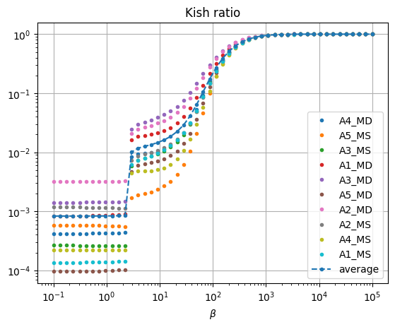

```python
matplotlib.rcdefaults()

for name in set(kish_ratios.keys())-set(['average']):
    plt.plot(betas, kish_ratios[name], '.', label=name)

plt.plot(betas, kish_ratios['average'], '.--', label='average')

plt.xscale('log')
plt.title('Kish ratio')
plt.xlabel(r'$\beta$')
plt.legend()
plt.yscale('log')
plt.grid()
plt.show()
```

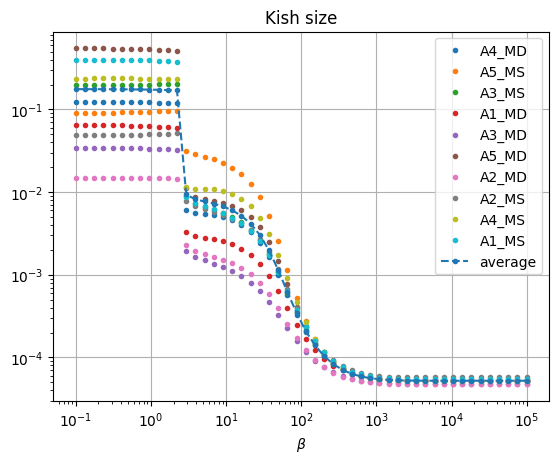

```python
matplotlib.rcdefaults()

for name in set(kish_sizes.keys())-set(['average']):
    plt.plot(betas, kish_sizes[name], '.', label=name)

plt.plot(betas, kish_sizes['average'], '.--', label='average')

plt.xscale('log')
plt.title('Kish size')
plt.xlabel(r'$\beta$')
plt.legend()
plt.yscale('log')
plt.grid()
plt.show()
```

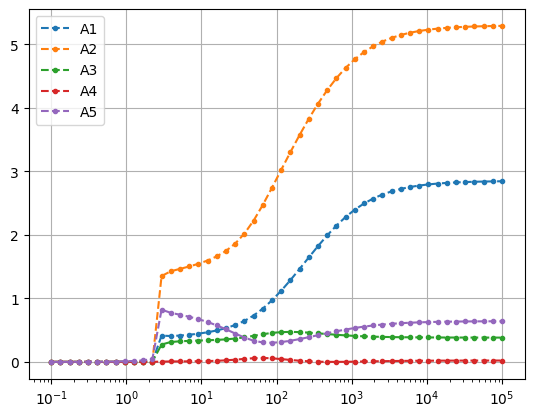

```python
matplotlib.rcdefaults()

for cycle_name in data.properties.cycle_names:
    chi2s = [Results_l2[i].chi2[cycle_name] for i in range(len(Results_l2))]
    plt.plot(betas, chi2s, '.--', label=cycle_name)

plt.xscale('log')
plt.legend()
plt.grid()
```

```python
df
```

[output not shown]

```python
font = {'weight' : 'bold', 'size' : 18}

matplotlib.rc('font', **font)
matplotlib.rcParams['lines.linewidth'] = 1
matplotlib.rcParams['lines.markersize'] = 10

fig, ax1 = plt.subplots(figsize=(10, 8))
ax2 = ax1.twinx()

chi2s = {}
for cycle_name in data.properties.cycle_names:
    chi2s[cycle_name] = [Results_l2[i].chi2[cycle_name] for i in range(len(Results_l2))]
    ax1.plot(betas, chi2s[cycle_name], '.-', label=cycle_name)

ax2.plot(betas, kish_ratios['average'], 'd--', label='av. KSR')

ax1.set_xscale('log')
ax1.set_xlabel(r'$\beta$')
ax1.grid(axis='x')

ax1.set_ylabel('$\chi^2$')
ax2.set_ylabel('Kish Size Ratio (KSR)')
ax2.set_yscale('log')

# ax1.set_ylim('low': 0)#[-0.45, 0.35])
# ax2.set_ylim([1.4, 2.5])

ax1.legend()#loc='upper right')
ax2.legend(loc='center left')

# plt.title('$\Delta Q$ parameters')
# plt.xlabel('$\beta$')
# plt.legend()
# plt.grid()
plt.show()

# plt.savefig('../../Figures/alchemical_L2_Kish_chi2.png')
```

[output not shown]

```python
arr = np.vstack((np.array(loss), kish_ratios['average'], [chi2s[cycle_name] for cycle_name in data.properties.cycle_names])).T
df = pandas.DataFrame(arr)
df.columns = ['loss', 'kish ratio'] + ['chi2s ' + name for name in data['global'].cycle_names]
df.index = betas

# df.to_csv('Results/alchemical_calculations/values_L2charges')
```

#### relative entropy regularization

```python
regularization = {'force_field_reg': 'KL divergence'}
```

```python
betas = [1e-3, 5e-3, 2e-2, 5e-2, 0.1, 0.5, 1, 5, 10, 50, 100, 500, 1e3, 5e3, 1e4, 5e4, 1e5, 5e5, 1e6, 5e6]
```

```python
log10_betas = np.linspace(-3, 7, 50)
betas = 10**log10_betas

print(betas)
```

```
[1.00000000e-03 1.59985872e-03 2.55954792e-03 4.09491506e-03
 6.55128557e-03 1.04811313e-02 1.67683294e-02 2.68269580e-02
 4.29193426e-02 6.86648845e-02 1.09854114e-01 1.75751062e-01
 2.81176870e-01 4.49843267e-01 7.19685673e-01 1.15139540e+00
 1.84206997e+00 2.94705170e+00 4.71486636e+00 7.54312006e+00
 1.20679264e+01 1.93069773e+01 3.08884360e+01 4.94171336e+01
 7.90604321e+01 1.26485522e+02 2.02358965e+02 3.23745754e+02
 5.17947468e+02 8.28642773e+02 1.32571137e+03 2.12095089e+03
 3.39322177e+03 5.42867544e+03 8.68511374e+03 1.38949549e+04
 2.22299648e+04 3.55648031e+04 5.68986603e+04 9.10298178e+04
 1.45634848e+05 2.32995181e+05 3.72759372e+05 5.96362332e+05
 9.54095476e+05 1.52641797e+06 2.44205309e+06 3.90693994e+06
 6.25055193e+06 1.00000000e+07]
```

```python
Results = {}

for beta in betas:
    print('beta: ', beta)

    Results[beta] = minimizer(data, regularization=regularization, beta=beta)

    clear_output()
```

Results = Parallel(n_jobs=10, verbose=1)(delayed(minimizer)( data, regularization=regularization, beta=beta) for beta in betas)

```python
print([Results[beta].mini.success for beta in betas])
```

[output not shown]

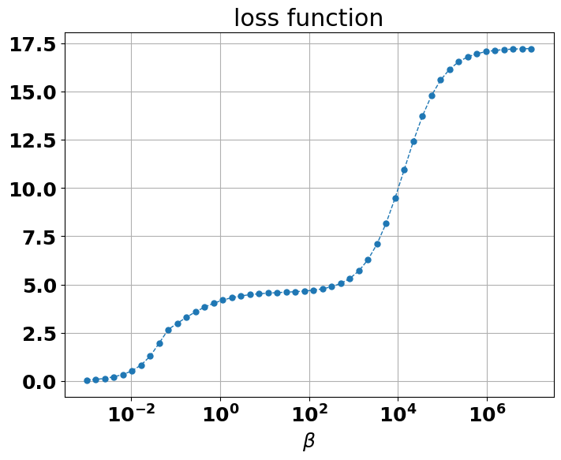

```python
loss = [Results[beta].loss for beta in betas]

font = {'weight' : 'bold', 'size' : 18}

matplotlib.rc('font', **font)
matplotlib.rcParams['lines.linewidth'] = 1
matplotlib.rcParams['lines.markersize'] = 10

plt.figure(figsize=(8, 6))

plt.plot(betas, loss, '.--')
plt.xscale('log')
plt.title('loss function')
plt.xlabel(r'$\beta$')
plt.grid()
# plt.show()

# plt.savefig('../../Figures/alchemical_DKL_loss.png')
```

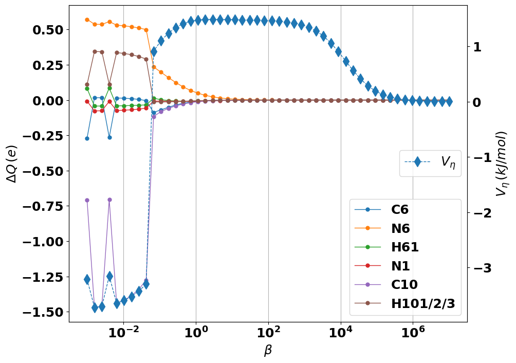

```python
font = {'weight' : 'bold', 'size' : 18}

matplotlib.rc('font', **font)
matplotlib.rcParams['lines.linewidth'] = 1
matplotlib.rcParams['lines.markersize'] = 10

fig, ax1 = plt.subplots(figsize=(10, 8))
ax2 = ax1.twinx()

# due to the constraint: total charge = 0
C6_charges = [(-np.sum(Results[beta].pars[:-1]) - 2*Results[beta].pars[-2]) for beta in betas]
ax1.plot(betas, C6_charges, '.-', label='C6')

for j in range(len(names_charges)):
    ax1.plot(betas, [Results[beta].pars[j] for beta in betas], '.-', label=names_charges[j])

ax2.plot(betas, [Results[beta].pars[-1] for beta in betas], 'd--', label='$V_\eta$')

ax1.set_xscale('log')
# ax1.set_yscale('symlog')
ax1.set_xlabel(r'$\beta$')
ax1.grid(axis='x')

ax1.set_ylabel('$\Delta Q \, (e)$')
ax2.set_ylabel('$V_\eta \, (kJ/mol)$')

# ax1.set_ylim([-0.45, 0.35])
# ax2.set_ylim([1.4, 2.5])

ax1.legend(loc='lower right')
ax2.legend(loc='center right')

# plt.title('$\Delta Q$ parameters')
# plt.xlabel('$\beta$')
# plt.legend()
# plt.grid()
# plt.show()

# plt.savefig('../../Figures/alchemical_DKL_parameters.png')
```

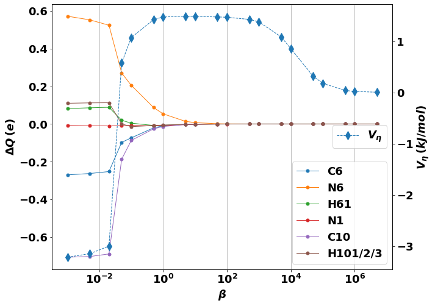

```python
font = {'weight' : 'bold', 'size' : 18}

matplotlib.rc('font', **font)
matplotlib.rcParams['lines.linewidth'] = 1
matplotlib.rcParams['lines.markersize'] = 10

fig, ax1 = plt.subplots(figsize=(10, 8))
ax2 = ax1.twinx()

# due to the constraint: total charge = 0
C6_charges = [(-np.sum(Results[beta].pars[:-1]) - 2*Results[beta].pars[-2]) for beta in betas]
ax1.plot(betas, C6_charges, '.-', label='C6')

for j in range(len(names_charges)):
    ax1.plot(betas, [Results[beta].pars[j] for beta in betas], '.-', label=names_charges[j])

ax2.plot(betas, [Results[beta].pars[-1] for beta in betas], 'd--', label='$V_\eta$')

ax1.set_xscale('log')
# ax1.set_yscale('symlog')
ax1.set_xlabel(r'$\beta$')
ax1.grid(axis='x')

ax1.set_ylabel('$\Delta Q \, (e)$')
ax2.set_ylabel('$V_\eta \, (kJ/mol)$')

# ax1.set_ylim([-0.45, 0.35])
# ax2.set_ylim([1.4, 2.5])

ax1.legend(loc='lower right')
ax2.legend(loc='center right')

# plt.title('$\Delta Q$ parameters')
# plt.xlabel('$\beta$')
# plt.legend()
# plt.grid()
# plt.show()

# plt.savefig('../../Figures/alchemical_DKL_parameters.png')
```

```python
vec = np.array([Results[beta].pars for beta in Results.keys()])

df = pandas.DataFrame(vec[:,:-1], columns=[n + ' (e)' for n in names_charges])
df['C6 (e)'] = C6_charges
df[r'$V_\eta (kJ/mol)$'] = vec[:, -1]
df.index = Results.keys()

# df.to_csv('Results/alchemical_calculations/coefficients_DKL')
```

```python
names = []

for name_sys in data.properties.system_names:
    if name_sys[-2] == 'M':
        names.append(name_sys)

kish_ratios = {}

for name_sys in names:
    kish_ratios[name_sys] = []
    for beta in betas:
        ratio = np.sum(data.mol[name_sys].weights**2)/np.sum(Results[beta].weights_new[name_sys]**2)
        kish_ratios[name_sys].append(ratio)
```

```python
kish_ratios['average'] = []

for i in range(len(Results)):
    kish_ratios['average'].append(np.mean([kish_ratios[name_sys][i] for name_sys in names]))
```

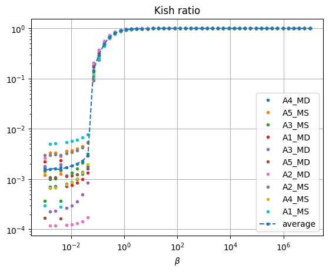

```python
matplotlib.rcdefaults()

for name in set(kish_ratios.keys())-set(['average']):
    plt.plot(betas, kish_ratios[name], '.', label=name)

plt.plot(betas, kish_ratios['average'], '.--', label='average')

plt.xscale('log')
plt.title('Kish ratio')
plt.xlabel(r'$\beta$')
plt.legend()
plt.yscale('log')
plt.grid()
plt.show()
```

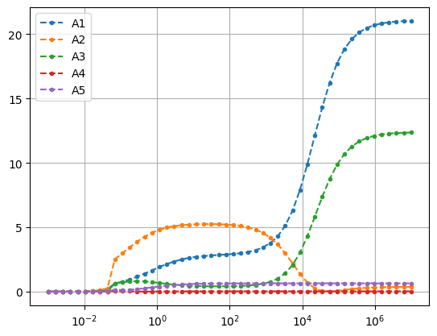

```python
chi2s = {}

for cycle_name in data.properties.cycle_names:
    chi2s[cycle_name] = [Results[beta].chi2[cycle_name] for beta in betas]
    plt.plot(betas, chi2s[cycle_name], '.--', label=cycle_name)

plt.xscale('log')
plt.legend()
plt.grid()
```

```python
arr = np.vstack((np.array(loss), kish_ratios['average'], [chi2s[cycle_name] for cycle_name in data.properties.cycle_names])).T
df = pandas.DataFrame(arr)
df.columns = ['loss', 'kish ratio'] + ['chi2s ' + name for name in data.properties.cycle_names]
df.index = betas

# df.to_csv('Results/alchemical_calculations/values_DKL')
```

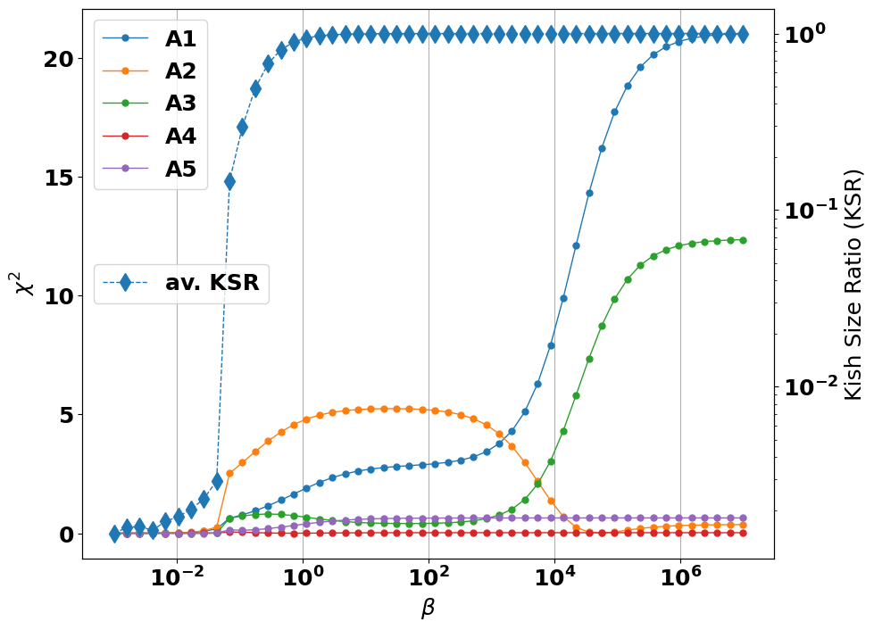

```python
font = {'weight' : 'bold', 'size' : 18}

matplotlib.rc('font', **font)
matplotlib.rcParams['lines.linewidth'] = 1
matplotlib.rcParams['lines.markersize'] = 10

fig, ax1 = plt.subplots(figsize=(10, 8))
ax2 = ax1.twinx()

for cycle_name in data.properties.cycle_names:
    chi2s = [Results[beta].chi2[cycle_name] for beta in betas]
    ax1.plot(betas, chi2s, '.-', label=cycle_name)

ax2.plot(betas, kish_ratios['average'], 'd--', label='av. KSR')

ax1.set_xscale('log')
ax1.set_xlabel(r'$\beta$')
ax1.grid(axis='x')

ax1.set_ylabel('$\chi^2$')
ax2.set_ylabel('Kish Size Ratio (KSR)')
ax2.set_yscale('log')

# ax1.set_ylim('low': 0)#[-0.45, 0.35])
# ax2.set_ylim([1.4, 2.5])

ax1.legend()#loc='upper right')
ax2.legend(loc='center left')

# plt.title('$\Delta Q$ parameters')
# plt.xlabel('$\beta$')
# plt.legend()
# plt.grid()
# plt.show()

# plt.savefig('../../Figures/alchemical_DKL_Kish_chi2.png')
```

### c. Analyse saved data

|  | loss | kish ratio | chi2s A1 | chi2s A2 | chi2s A3 | chi2s A4 | chi2s A5 | chi2 tot |
| --- | --- | --- | --- | --- | --- | --- | --- | --- |
| 0.100000 | 0.024849 | 0.000830 | 0.000007 | 0.000002 | 0.000016 | 0.000002 | 0.000096 | 0.000122 |
| 0.132571 | 0.032917 | 0.000830 | 0.000012 | 0.000003 | 0.000028 | 0.000003 | 0.000168 | 0.000213 |
| 0.175751 | 0.043592 | 0.000831 | 0.000021 | 0.000006 | 0.000048 | 0.000005 | 0.000294 | 0.000373 |
| 0.232995 | 0.057710 | 0.000831 | 0.000037 | 0.000009 | 0.000083 | 0.000008 | 0.000516 | 0.000654 |
| 0.308884 | 0.076367 | 0.000831 | 0.000064 | 0.000016 | 0.000143 | 0.000014 | 0.000901 | 0.001139 |
| 0.409492 | 0.100995 | 0.000832 | 0.000113 | 0.000026 | 0.000246 | 0.000025 | 0.001574 | 0.001984 |
| 0.542868 | 0.133465 | 0.000832 | 0.000199 | 0.000040 | 0.000416 | 0.000044 | 0.002746 | 0.003445 |
| 0.719686 | 0.176198 | 0.000833 | 0.000352 | 0.000060 | 0.000699 | 0.000076 | 0.004780 | 0.005967 |
| 0.954095 | 0.232311 | 0.000835 | 0.000620 | 0.000084 | 0.001158 | 0.000132 | 0.008297 | 0.010291 |
| 1.264855 | 0.305782 | 0.000837 | 0.001095 | 0.000109 | 0.001887 | 0.000226 | 0.014351 | 0.017668 |
| 1.676833 | 0.401619 | 0.000840 | 0.001935 | 0.000119 | 0.003007 | 0.000383 | 0.024732 | 0.030176 |
| 2.222996 | 0.526031 | 0.000846 | 0.003423 | 0.000096 | 0.004660 | 0.000636 | 0.042400 | 0.051216 |
| 2.947052 | 1.563182 | 0.010037 | 0.413090 | 1.350769 | 0.272775 | 0.004204 | 0.821926 | 2.862765 |
| 3.906940 | 1.599933 | 0.011744 | 0.406762 | 1.425797 | 0.312672 | 0.006800 | 0.771761 | 2.923793 |
| 5.179475 | 1.642721 | 0.012573 | 0.414139 | 1.463411 | 0.323821 | 0.007555 | 0.741871 | 2.950798 |
| 6.866488 | 1.695262 | 0.013440 | 0.426664 | 1.500779 | 0.330290 | 0.008479 | 0.710065 | 2.976276 |
| 9.102982 | 1.760561 | 0.014557 | 0.443747 | 1.543361 | 0.335235 | 0.010061 | 0.672651 | 3.005054 |
| 12.067926 | 1.841924 | 0.016139 | 0.465920 | 1.594942 | 0.340063 | 0.012796 | 0.627690 | 3.041412 |
| 15.998587 | 1.942865 | 0.018530 | 0.494474 | 1.660248 | 0.345931 | 0.017324 | 0.574225 | 3.092201 |
| 21.209509 | 2.066597 | 0.022372 | 0.531474 | 1.745961 | 0.354300 | 0.024410 | 0.512765 | 3.168910 |
| 28.117687 | 2.215022 | 0.028973 | 0.579980 | 1.861451 | 0.367018 | 0.034588 | 0.446508 | 3.289545 |
| 37.275937 | 2.387223 | 0.041079 | 0.644224 | 2.017926 | 0.385779 | 0.047047 | 0.382919 | 3.477895 |
| 49.417134 | 2.578244 | 0.063986 | 0.729080 | 2.222662 | 0.410140 | 0.057985 | 0.333152 | 3.753019 |
| 65.512856 | 2.780047 | 0.105575 | 0.837531 | 2.469471 | 0.435578 | 0.061697 | 0.305872 | 4.110149 |
| 86.851137 | 2.984734 | 0.173265 | 0.968702 | 2.740989 | 0.455981 | 0.056075 | 0.300684 | 4.522431 |
| 115.139540 | 3.186364 | 0.269229 | 1.119581 | 3.021177 | 0.468066 | 0.044185 | 0.311454 | 4.964464 |
| 152.641797 | 3.380440 | 0.387406 | 1.285946 | 3.299966 | 0.471732 | 0.030487 | 0.332123 | 5.420254 |
| 202.358965 | 3.563178 | 0.514920 | 1.462730 | 3.570234 | 0.468430 | 0.018207 | 0.358710 | 5.878311 |
| 268.269580 | 3.731364 | 0.637212 | 1.643683 | 3.826097 | 0.460250 | 0.008966 | 0.388651 | 6.327647 |
| 355.648031 | 3.882547 | 0.743093 | 1.821811 | 4.062671 | 0.449354 | 0.003160 | 0.420080 | 6.757076 |
| 471.486636 | 4.015265 | 0.827070 | 1.990516 | 4.276063 | 0.437643 | 0.000440 | 0.451464 | 7.156126 |
| 625.055193 | 4.129135 | 0.888917 | 2.144369 | 4.464045 | 0.426459 | 0.000105 | 0.481482 | 7.516459 |
| 828.642773 | 4.224769 | 0.931715 | 2.279918 | 4.625880 | 0.416613 | 0.001377 | 0.509119 | 7.832907 |
| 1098.541142 | 4.303559 | 0.959811 | 2.395729 | 4.762276 | 0.408429 | 0.003564 | 0.533706 | 8.103703 |
| 1456.348478 | 4.367388 | 0.977435 | 2.492112 | 4.875051 | 0.401912 | 0.006135 | 0.554927 | 8.330136 |
| 1930.697729 | 4.418362 | 0.988045 | 2.570599 | 4.966729 | 0.396873 | 0.008727 | 0.572772 | 8.515701 |
| 2559.547923 | 4.458586 | 0.994180 | 2.633403 | 5.040182 | 0.393058 | 0.011126 | 0.587451 | 8.665219 |
| 3393.221772 | 4.490018 | 0.997574 | 2.682968 | 5.098316 | 0.390202 | 0.013225 | 0.599307 | 8.784017 |
| 4498.432669 | 4.514388 | 0.999350 | 2.721661 | 5.143853 | 0.388081 | 0.014993 | 0.608741 | 8.877330 |
| 5963.623317 | 4.533164 | 1.000205 | 2.751621 | 5.179233 | 0.386510 | 0.016440 | 0.616159 | 8.949962 |
| 7906.043211 | 4.547560 | 1.000556 | 2.774669 | 5.206541 | 0.385346 | 0.017602 | 0.621937 | 9.006095 |
| 10481.131342 | 4.558555 | 1.000646 | 2.792316 | 5.227506 | 0.384482 | 0.018519 | 0.626404 | 9.049227 |
| 13894.954944 | 4.566928 | 1.000610 | 2.805779 | 5.243537 | 0.383841 | 0.019236 | 0.629837 | 9.082230 |
| 18420.699693 | 4.573290 | 1.000523 | 2.816021 | 5.255755 | 0.383363 | 0.019791 | 0.632465 | 9.107394 |
| 24420.530945 | 4.578115 | 1.000422 | 2.823796 | 5.265044 | 0.383005 | 0.020218 | 0.634468 | 9.126532 |
| 32374.575428 | 4.581770 | 1.000325 | 2.829689 | 5.272093 | 0.382738 | 0.020545 | 0.635992 | 9.141058 |
| 42919.342601 | 4.584536 | 1.000241 | 2.834151 | 5.277435 | 0.382538 | 0.020794 | 0.637149 | 9.152067 |
| 56898.660290 | 4.586627 | 1.000170 | 2.837526 | 5.281478 | 0.382387 | 0.020984 | 0.638026 | 9.160401 |
| 75431.200634 | 4.588207 | 1.000113 | 2.840077 | 5.284535 | 0.382274 | 0.021128 | 0.638690 | 9.166704 |
| 100000.000000 | 4.589401 | 1.000068 | 2.842004 | 5.286846 | 0.382189 | 0.021237 | 0.639192 | 9.171469 |

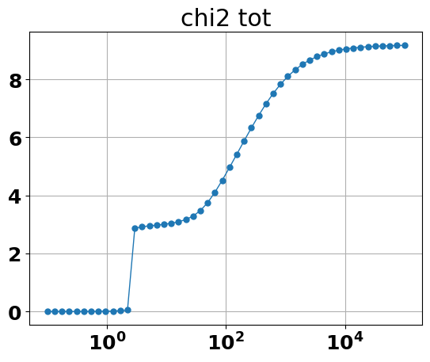

```python
df = pandas.read_csv('Results/alchemical_calculations/values_L2charges', index_col=0)

my_list = [s for s in df.columns if s.startswith('chi2s')]
df['chi2 tot'] = np.sum(np.array(df[my_list]), axis=1)

plt.plot(df['chi2 tot'], '.-')
plt.xscale('log')
plt.title('chi2 tot')
plt.grid()

df
```

|  | loss | kish ratio | chi2s A1 | chi2s A2 | chi2s A3 | chi2s A4 | chi2s A5 | chi2 tot | Kish size A1_MS | D_KL A1_MS | ... | D_KL A3_MD | Kish size A4_MS | D_KL A4_MS | Kish size A4_MD | D_KL A4_MD | Kish size A5_MS | D_KL A5_MS | Kish size A5_MD | D_KL A5_MD | Kish size tot |
| --- | --- | --- | --- | --- | --- | --- | --- | --- | --- | --- | --- | --- | --- | --- | --- | --- | --- | --- | --- | --- | --- |
| 1.000000e-03 | 0.053460 | 0.001481 | 0.000010 | 0.000071 | 0.000027 | 0.000150 | 6.566004e-06 | 0.000265 | 3847.775179 | 6.505530e+00 | ... | 4.471916e+00 | 722.771000 | 5.117847e+00 | 800.053626 | 4.974837e+00 | 859.270952 | 5.516009e+00 | 5073.489942 | 7.015897e+00 | 16653.141175 |
| 1.599859e-03 | 0.082262 | 0.001594 | 0.000359 | 0.000426 | 0.000003 | 0.000008 | 3.201807e-07 | 0.000796 | 179.976280 | 3.649131e+00 | ... | 6.039718e+00 | 4203.386744 | 5.653122e+00 | 2995.542726 | 5.381964e+00 | 1341.236848 | 4.194227e+00 | 990.940989 | 4.598464e+00 | 31944.198741 |
| 2.559548e-03 | 0.131226 | 0.001620 | 0.000912 | 0.001081 | 0.000008 | 0.000022 | 5.337159e-07 | 0.002023 | 177.702986 | 3.633958e+00 | ... | 5.987086e+00 | 4077.916730 | 5.613535e+00 | 2935.334884 | 5.347842e+00 | 1272.543191 | 4.170281e+00 | 977.095884 | 4.577694e+00 | 31262.271637 |
| 4.094915e-03 | 0.217569 | 0.001537 | 0.000304 | 0.001013 | 0.000208 | 0.001270 | 2.008740e-04 | 0.002995 | 4022.633525 | 6.502109e+00 | ... | 4.379569e+00 | 705.779279 | 5.076246e+00 | 790.570843 | 4.948107e+00 | 788.806156 | 5.439796e+00 | 5030.264310 | 6.982268e+00 | 16498.265587 |
| 6.551286e-03 | 0.331906 | 0.001728 | 0.005757 | 0.006880 | 0.000053 | 0.000157 | 8.506679e-09 | 0.012847 | 169.064942 | 3.573406e+00 | ... | 5.772505e+00 | 3599.549433 | 5.453778e+00 | 2705.574443 | 5.210455e+00 | 1030.912100 | 4.076351e+00 | 922.923405 | 4.493729e+00 | 28625.550772 |
| 1.048113e-02 | 0.524926 | 0.001837 | 0.014236 | 0.017163 | 0.000145 | 0.000424 | 6.146445e-06 | 0.031973 | 161.629507 | 3.517200e+00 | ... | 5.567537e+00 | 3189.121865 | 5.303458e+00 | 2507.726239 | 5.081612e+00 | 848.523024 | 3.991546e+00 | 874.117076 | 4.414199e+00 | 26301.879186 |
| 1.676833e-02 | 0.824777 | 0.002017 | 0.034517 | 0.042417 | 0.000430 | 0.001136 | 9.896608e-05 | 0.078598 | 151.410243 | 3.432864e+00 | ... | 5.252531e+00 | 2639.052334 | 5.076178e+00 | 2238.708891 | 4.887243e+00 | 637.856318 | 3.868402e+00 | 803.164541 | 4.291639e+00 | 23047.149399 |
| 2.682696e-02 | 1.282858 | 0.002327 | 0.081201 | 0.104124 | 0.001492 | 0.002895 | 7.748682e-04 | 0.190487 | 137.970781 | 3.308088e+00 | ... | 4.782186e+00 | 1974.692900 | 4.742184e+00 | 1894.294235 | 4.600308e+00 | 430.480373 | 3.693949e+00 | 702.861094 | 4.103253e+00 | 18758.911242 |
| 4.291934e-02 | 1.964035 | 0.002930 | 0.182896 | 0.257990 | 0.006666 | 0.006427 | 3.919528e-03 | 0.457899 | 120.342999 | 3.121864e+00 | ... | 4.116035e+00 | 1280.507333 | 4.264764e+00 | 1454.352226 | 4.177847e+00 | 261.987164 | 3.444771e+00 | 563.830287 | 3.809842e+00 | 13501.753010 |
| 6.866488e-02 | 2.670122 | 0.146076 | 0.634343 | 2.519636 | 0.632277 | 0.050948 | 1.419050e-01 | 3.979108 | 8.854846 | 1.079901e+00 | ... | 7.801170e-01 | 7.969293 | 1.088100e+00 | 6.218812 | 9.770538e-01 | 10.181598 | 1.097551e+00 | 7.109910 | 1.004420e+00 | 76.213708 |
| 1.098541e-01 | 2.990679 | 0.295917 | 0.768492 | 2.969304 | 0.724339 | 0.040803 | 1.241338e-01 | 4.627072 | 3.871122 | 6.644576e-01 | ... | 4.924088e-01 | 3.819445 | 6.726164e-01 | 3.258846 | 6.120902e-01 | 4.085696 | 6.721112e-01 | 3.445655 | 6.278165e-01 | 35.390016 |
| 1.757511e-01 | 3.300184 | 0.490295 | 0.942802 | 3.433913 | 0.786590 | 0.023707 | 1.451479e-01 | 5.332160 | 2.195750 | 3.877007e-01 | ... | 2.888667e-01 | 2.207553 | 3.910354e-01 | 2.032820 | 3.611142e-01 | 2.233156 | 3.919169e-01 | 2.091849 | 3.711968e-01 | 20.815587 |
| 2.811769e-01 | 3.582111 | 0.673685 | 1.153606 | 3.875609 | 0.809295 | 0.009125 | 1.920299e-01 | 6.039665 | 1.544738 | 2.162129e-01 | ... | 1.582603e-01 | 1.549092 | 2.160567e-01 | 1.491794 | 2.020341e-01 | 1.554291 | 2.179031e-01 | 1.514493 | 2.081327e-01 | 14.965110 |
| 4.498433e-01 | 3.826394 | 0.809163 | 1.393039 | 4.260564 | 0.790456 | 0.001465 | 2.551398e-01 | 6.700664 | 1.260638 | 1.159952e-01 | ... | 8.182778e-02 | 1.259563 | 1.145096e-01 | 1.239234 | 1.080545e-01 | 1.262876 | 1.160343e-01 | 1.248781 | 1.114450e-01 | 12.364220 |
| 7.196857e-01 | 4.029051 | 0.894520 | 1.648483 | 4.571375 | 0.738928 | 0.000131 | 3.258072e-01 | 7.284725 | 1.126627 | 5.994280e-02 | ... | 4.026680e-02 | 1.124296 | 5.843588e-02 | 1.116487 | 5.545158e-02 | 1.126276 | 5.931045e-02 | 1.120623 | 5.718216e-02 | 11.133910 |
| 1.151395e+00 | 4.190573 | 0.943365 | 1.902695 | 4.805616 | 0.670028 | 0.002634 | 3.960683e-01 | 7.777040 | 1.060990 | 2.979733e-02 | ... | 1.900984e-02 | 1.059085 | 2.872767e-02 | 1.055863 | 2.733264e-02 | 1.060018 | 2.912173e-02 | 1.057635 | 2.814511e-02 | 10.537592 |
| 1.842070e+00 | 4.314487 | 0.969870 | 2.137137 | 4.971922 | 0.599205 | 0.006638 | 4.595019e-01 | 8.174404 | 1.028690 | 1.422967e-02 | ... | 8.684015e-03 | 1.027514 | 1.360310e-02 | 1.026113 | 1.294924e-02 | 1.027870 | 1.374716e-02 | 1.026844 | 1.330052e-02 | 10.249241 |
| 2.947052e+00 | 4.406200 | 0.983892 | 2.337281 | 5.084408 | 0.537208 | 0.010654 | 5.121539e-01 | 8.481705 | 1.013100 | 6.539920e-03 | ... | 3.880583e-03 | 1.012481 | 6.218597e-03 | 1.011856 | 5.915132e-03 | 1.012591 | 6.260049e-03 | 1.012140 | 6.054544e-03 | 10.112596 |
| 4.714866e+00 | 4.472094 | 0.991249 | 2.496238 | 5.157554 | 0.488712 | 0.013997 | 5.527782e-01 | 8.709278 | 1.005831 | 2.918108e-03 | ... | 1.727974e-03 | 1.005539 | 2.769070e-03 | 1.005258 | 2.629923e-03 | 1.005564 | 2.776672e-03 | 1.005358 | 2.679680e-03 | 10.049857 |
| 7.543120e+00 | 4.518736 | 0.995129 | 2.615201 | 5.203168 | 0.453822 | 0.016504 | 5.822929e-01 | 8.870988 | 1.002573 | 1.289188e-03 | ... | 7.935290e-04 | 1.002447 | 1.225199e-03 | 1.002319 | 1.161110e-03 | 1.002449 | 1.224647e-03 | 1.002348 | 1.175768e-03 | 10.022062 |
| 1.206793e+01 | 4.552256 | 0.997210 | 2.700772 | 5.229626 | 0.430411 | 0.018266 | 6.027579e-01 | 8.981833 | 1.001168 | 5.855206e-04 | ... | 3.981716e-04 | 1.001116 | 5.594969e-04 | 1.001054 | 5.286259e-04 | 1.001115 | 5.585830e-04 | 1.001059 | 5.307103e-04 | 10.010156 |
| 1.930698e+01 | 4.578072 | 0.998354 | 2.761695 | 5.242150 | 0.415915 | 0.019454 | 6.164696e-01 | 9.055684 | 1.000580 | 2.910998e-04 | ... | 2.338738e-04 | 1.000559 | 2.806505e-04 | 1.000526 | 2.640995e-04 | 1.000560 | 2.810655e-04 | 1.000522 | 2.622771e-04 | 10.005195 |
| 3.088844e+01 | 4.601016 | 0.999002 | 2.806662 | 5.243293 | 0.408274 | 0.020233 | 6.254389e-01 | 9.103900 | 1.000339 | 1.707530e-04 | ... | 1.661906e-04 | 1.000330 | 1.661629e-04 | 1.000309 | 1.556915e-04 | 1.000334 | 1.678885e-04 | 1.000304 | 1.530394e-04 | 10.003170 |
| 4.941713e+01 | 4.625803 | 0.999379 | 2.843568 | 5.233234 | 0.406281 | 0.020735 | 6.312134e-01 | 9.135031 | 1.000242 | 1.222677e-04 | ... | 1.381880e-04 | 1.000237 | 1.196321e-04 | 1.000221 | 1.117408e-04 | 1.000242 | 1.223179e-04 | 1.000216 | 1.092166e-04 | 10.002352 |
| 7.906043e+01 | 4.657765 | 0.999603 | 2.879755 | 5.209786 | 0.409724 | 0.021055 | 6.348930e-01 | 9.155212 | 1.000203 | 1.027667e-04 | ... | 1.262460e-04 | 1.000199 | 1.006371e-04 | 1.000186 | 9.386372e-05 | 1.000206 | 1.039572e-04 | 1.000181 | 9.167767e-05 | 10.002021 |
| 1.264855e+02 | 4.703839 | 0.999739 | 2.922947 | 5.167964 | 0.419527 | 0.021258 | 6.372238e-01 | 9.168919 | 1.000187 | 9.465991e-05 | ... | 1.206387e-04 | 1.000183 | 9.256120e-05 | 1.000171 | 8.630342e-05 | 1.000190 | 9.627393e-05 | 1.000167 | 8.443396e-05 | 10.001881 |
| 2.023590e+02 | 4.773906 | 0.999823 | 2.982644 | 5.099123 | 0.438094 | 0.021386 | 6.386973e-01 | 9.179944 | 1.000179 | 9.078687e-05 | ... | 1.172931e-04 | 1.000175 | 8.860530e-05 | 1.000163 | 8.262418e-05 | 1.000183 | 9.253920e-05 | 1.000160 | 8.099961e-05 | 10.001812 |
| 3.237458e+02 | 4.882576 | 0.999875 | 3.072057 | 4.989692 | 0.470011 | 0.021468 | 6.396315e-01 | 9.192860 | 1.000174 | 8.816350e-05 | ... | 1.143670e-04 | 1.000170 | 8.590930e-05 | 1.000158 | 8.012631e-05 | 1.000178 | 8.993782e-05 | 1.000156 | 7.868206e-05 | 10.001762 |
| 5.179475e+02 | 5.051459 | 0.999910 | 3.210830 | 4.819754 | 0.523399 | 0.021521 | 6.402311e-01 | 9.215735 | 1.000169 | 8.541110e-05 | ... | 1.108380e-04 | 1.000164 | 8.313365e-05 | 1.000153 | 7.755070e-05 | 1.000172 | 8.715242e-05 | 1.000151 | 7.624337e-05 | 10.001707 |
| 8.286428e+02 | 5.311647 | 0.999934 | 3.428875 | 4.562323 | 0.612327 | 0.021556 | 6.406279e-01 | 9.265708 | 1.000162 | 8.171602e-05 | ... | 1.059277e-04 | 1.000157 | 7.947795e-05 | 1.000147 | 7.414873e-05 | 1.000165 | 8.338672e-05 | 1.000144 | 7.295661e-05 | 10.001633 |
| 1.325711e+03 | 5.705321 | 0.999953 | 3.771368 | 4.185359 | 0.760892 | 0.021583 | 6.409082e-01 | 9.380110 | 1.000151 | 7.643827e-05 | ... | 9.890027e-05 | 1.000147 | 7.431031e-05 | 1.000137 | 6.933125e-05 | 1.000154 | 7.800018e-05 | 1.000135 | 6.825149e-05 | 10.001527 |
| 2.120951e+03 | 6.283884 | 0.999969 | 4.303824 | 3.660182 | 1.009093 | 0.021604 | 6.411298e-01 | 9.635833 | 1.000137 | 6.904473e-05 | ... | 8.910132e-05 | 1.000133 | 6.710486e-05 | 1.000124 | 6.260858e-05 | 1.000139 | 7.045325e-05 | 1.000122 | 6.165332e-05 | 10.001378 |
| 3.393222e+03 | 7.098199 | 0.999985 | 5.112887 | 2.979986 | 1.418316 | 0.021626 | 6.413314e-01 | 10.174147 | 1.000117 | 5.927232e-05 | ... | 7.622450e-05 | 1.000114 | 5.759995e-05 | 1.000106 | 5.373793e-05 | 1.000120 | 6.047900e-05 | 1.000105 | 5.292834e-05 | 10.001182 |
| 5.428675e+03 | 8.176838 | 1.000000 | 6.292426 | 2.185908 | 2.068105 | 0.021648 | 6.415375e-01 | 11.209625 | 1.000094 | 4.745040e-05 | ... | 6.074956e-05 | 1.000091 | 4.611068e-05 | 1.000085 | 4.301499e-05 | 1.000096 | 4.841416e-05 | 1.000084 | 4.237173e-05 | 10.000945 |
| 8.685114e+03 | 9.495911 | 1.000014 | 7.902418 | 1.381078 | 3.029840 | 0.021673 | 6.417575e-01 | 12.976768 | 1.000069 | 3.474218e-05 | ... | 4.424118e-05 | 1.000067 | 3.376312e-05 | 1.000063 | 3.149228e-05 | 1.000070 | 3.544603e-05 | 1.000062 | 3.102318e-05 | 10.000691 |
| 1.389495e+04 | 10.959804 | 1.000023 | 9.905066 | 0.702841 | 4.312590 | 0.021700 | 6.419862e-01 | 15.584183 | 1.000046 | 2.291673e-05 | ... | 2.901033e-05 | 1.000044 | 2.227321e-05 | 1.000041 | 2.077193e-05 | 1.000046 | 2.337976e-05 | 1.000041 | 2.046305e-05 | 10.000455 |
| 2.222996e+04 | 12.419119 | 1.000026 | 12.127435 | 0.252411 | 5.816964 | 0.021726 | 6.422075e-01 | 18.860743 | 1.000027 | 1.354089e-05 | ... | 1.704105e-05 | 1.000026 | 1.316229e-05 | 1.000024 | 1.227314e-05 | 1.000027 | 1.381377e-05 | 1.000024 | 1.209073e-05 | 10.000268 |
| 3.556480e+04 | 13.726249 | 1.000025 | 14.309221 | 0.040576 | 7.355513 | 0.021749 | 6.424030e-01 | 22.369462 | 1.000014 | 7.209600e-06 | ... | 9.025697e-06 | 1.000014 | 7.008882e-06 | 1.000013 | 6.534446e-06 | 1.000015 | 7.354556e-06 | 1.000013 | 6.437316e-06 | 10.000143 |
| 5.689866e+04 | 14.789607 | 1.000020 | 16.216991 | 0.001882 | 8.740042 | 0.021767 | 6.425612e-01 | 25.623243 | 1.000007 | 3.512044e-06 | ... | 4.378021e-06 | 1.000007 | 3.414627e-06 | 1.000006 | 3.183099e-06 | 1.000007 | 3.582524e-06 | 1.000006 | 3.135770e-06 | 10.000069 |
| 9.102982e+04 | 15.589056 | 1.000015 | 17.729532 | 0.051712 | 9.859282 | 0.021781 | 6.426799e-01 | 28.304987 | 1.000003 | 1.595988e-06 | ... | 1.983157e-06 | 1.000003 | 1.551846e-06 | 1.000003 | 1.446489e-06 | 1.000003 | 1.627972e-06 | 1.000003 | 1.424974e-06 | 10.000032 |
| 1.456348e+05 | 16.155243 | 1.000011 | 18.841225 | 0.127944 | 10.692504 | 0.021791 | 6.427638e-01 | 30.326228 | 1.000001 | 6.894606e-07 | ... | 8.547769e-07 | 1.000001 | 6.704308e-07 | 1.000001 | 6.248727e-07 | 1.000001 | 7.032633e-07 | 1.000001 | 6.155759e-07 | 10.000014 |
| 2.329952e+05 | 16.539511 | 1.000007 | 19.614810 | 0.199006 | 11.277131 | 0.021798 | 6.428208e-01 | 31.755565 | 1.000001 | 2.875772e-07 | ... | 3.559838e-07 | 1.000001 | 2.796511e-07 | 1.000001 | 2.606361e-07 | 1.000001 | 2.933304e-07 | 1.000001 | 2.567576e-07 | 10.000006 |
| 3.727594e+05 | 16.792843 | 1.000005 | 20.133225 | 0.254394 | 11.670995 | 0.021802 | 6.428583e-01 | 32.723275 | 1.000000 | 1.171709e-07 | ... | 1.448958e-07 | 1.000000 | 1.139446e-07 | 1.000000 | 1.061936e-07 | 1.000000 | 1.195139e-07 | 1.000000 | 1.046132e-07 | 10.000002 |
| 5.963623e+05 | 16.956676 | 1.000003 | 20.472047 | 0.293825 | 11.929279 | 0.021805 | 6.428826e-01 | 33.359839 | 1.000000 | 4.701568e-08 | ... | 5.810242e-08 | 1.000000 | 4.572189e-08 | 1.000000 | 4.261089e-08 | 1.000000 | 4.795557e-08 | 1.000000 | 4.197667e-08 | 10.000001 |
| 9.540955e+05 | 17.061315 | 1.000002 | 20.689914 | 0.320493 | 12.095710 | 0.021807 | 6.428981e-01 | 33.770822 | 1.000000 | 1.868094e-08 | ... | 2.307643e-08 | 1.000000 | 1.816708e-08 | 1.000000 | 1.693075e-08 | 1.000000 | 1.905432e-08 | 1.000000 | 1.667873e-08 | 10.000000 |
| 1.526418e+06 | 17.127618 | 1.000001 | 20.828552 | 0.337990 | 12.201758 | 0.021808 | 6.429079e-01 | 34.033015 | 1.000000 | 7.376165e-09 | ... | 9.109313e-09 | 1.000000 | 7.173319e-09 | 1.000000 | 6.685098e-09 | 1.000000 | 7.523576e-09 | 1.000000 | 6.585586e-09 | 10.000000 |
| 2.442053e+06 | 17.169417 | 1.000001 | 20.916184 | 0.349258 | 12.268846 | 0.021809 | 6.429141e-01 | 34.199011 | 1.000000 | 2.901117e-09 | ... | 3.582181e-09 | 1.000000 | 2.821348e-09 | 1.000000 | 2.629312e-09 | 1.000000 | 2.959091e-09 | 1.000000 | 2.590172e-09 | 10.000000 |
| 3.906940e+06 | 17.195684 | 1.000000 | 20.971347 | 0.356434 | 12.311100 | 0.021809 | 6.429180e-01 | 34.303608 | 1.000000 | 1.138196e-09 | ... | 1.405250e-09 | 1.000000 | 1.106903e-09 | 1.000000 | 1.031558e-09 | 1.000000 | 1.160940e-09 | 1.000000 | 1.016202e-09 | 10.000000 |
| 6.250552e+06 | 17.212158 | 1.000000 | 21.005981 | 0.360971 | 12.337636 | 0.021810 | 6.429204e-01 | 34.369319 | 1.000000 | 4.458490e-10 | ... | 5.504224e-10 | 1.000000 | 4.335921e-10 | 1.000000 | 4.040778e-10 | 1.000000 | 4.547582e-10 | 1.000000 | 3.980624e-10 | 10.000000 |
| 1.000000e+07 | 17.222477 | 1.000000 | 21.027689 | 0.363828 | 12.354273 | 0.021810 | 6.429220e-01 | 34.410521 | 1.000000 | 1.744746e-10 | ... | 2.153886e-10 | 1.000000 | 1.696783e-10 | 1.000000 | 1.581284e-10 | 1.000000 | 1.779610e-10 | 1.000000 | 1.557742e-10 | 10.000000 |

50 rows × 29 columns

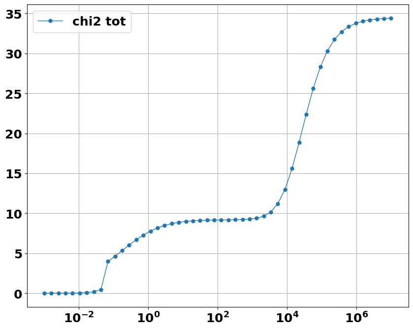

```python
df2 = pandas.read_csv('Results/alchemical_calculations/values_DKL', index_col=0)

my_list = [s for s in df2.columns if s.startswith('chi2s')]
df2['chi2 tot'] = np.sum(np.array(df2[my_list]), axis=1)

plt.figure(figsize=(10, 8))
# plt.plot(df['chi2 tot'], '.-', label='L2 reg. on charges')
plt.plot(df2['chi2 tot'], '.-', label='chi2 tot')
plt.xscale('log')
plt.legend()
plt.grid()

df2
```

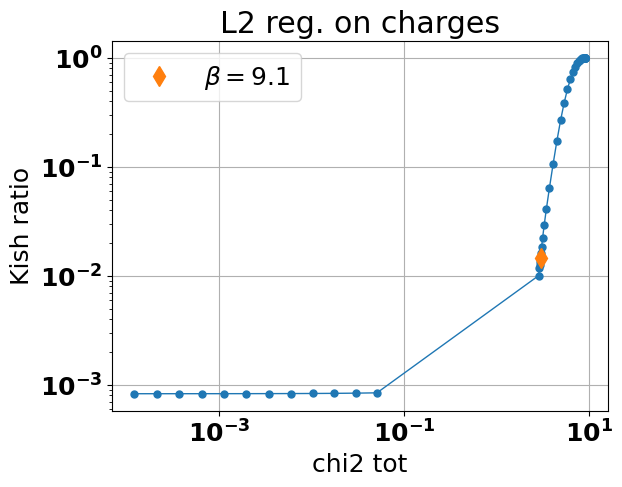

```python
plt.plot(df['chi2 tot'], df['kish ratio'], '.-')
val = 9.102981779915217 # the closest scanned value to 10
plt.plot(df['chi2 tot'][val], df['kish ratio'][val], 'd', label=r'$\beta=%.1f$' % val)
plt.xscale('log')
plt.yscale('log')
plt.grid()
plt.title('L2 reg. on charges')
plt.xlabel('chi2 tot')
plt.ylabel('Kish ratio')
plt.legend()
# plt.savefig('../../Figures/alchemical_L2charges_kish_vs_chi2.png')
```

[figure not shown]

```python
plt.plot(df['chi2 tot'], df['kish ratio'], '.-', label='L2 reg. on charges')
val = 10
plt.plot(df['chi2 tot'][val], df['kish ratio'][val], 'd', label=r'$\beta=%.1f$' % val)

plt.plot(df2['chi2 tot'], df2['kish ratio'], '.-', label='D KL reg.')
val2 = 0.05
plt.plot(df2['chi2 tot'][val2], df2['kish ratio'][val2], 'd', label=r'$\beta=%.2f$' % val2)

# plt.xscale('log')
# plt.yscale('log')
plt.grid()
# plt.title('relative entropy reg.')
plt.xlabel('chi2 tot')
plt.ylabel('Kish ratio')
plt.xlim(right=10)
plt.legend()
# plt.savefig('../../Figures/alchemical_DKL_kish_vs_chi2.png')
# plt.savefig('../../Figures/alchemical_kish_vs_chi2_linear_upxlimit.png')
```

#### compute Kish sizes and relative entropies

firstly, compute new weights from optimal coefficients

```python
from MDRefine import compute_new_weights, compute_D_KL
```

```python
coeffs_L2_df = pandas.read_csv('Results/alchemical_calculations/coefficients_L2charges', index_col=0)
coeffs_DKL_df = pandas.read_csv('Results/alchemical_calculations/coefficients_DKL', index_col=0)

betas = coeffs_L2_df.index

weights_L2 = {}
kish_size_L2 = {}
kish_ratio_L2 = {}
rel_entropy_L2 = {}

for i, beta in enumerate(betas):
    coeffs_L2 = list(coeffs_L2_df.iloc[i, :5]) + [coeffs_L2_df.iloc[i, 6]]

    weights_L2[beta] = {}
    kish_size_L2[beta] = {}
    kish_ratio_L2[beta] = {}
    rel_entropy_L2[beta] = {}

    for sys_name in data.properties.system_names:
        if hasattr(data.mol[sys_name], 'f'):
            wh = np.argwhere(data.mol[sys_name].weights != 0)
            w0 = data.mol[sys_name].weights[wh]
            weights_L2[beta][sys_name] = compute_new_weights(data.mol[sys_name].weights, ff_correction(coeffs_L2, data[sys_name].f)/data[sys_name].temperature)[0][wh]

            kish_size_L2[beta][sys_name] = np.sum(weights_L2[beta][sys_name]**2/w0)
            kish_ratio_L2[beta][sys_name] = np.sum(w0**2)/np.sum(weights_L2[beta][sys_name]**2)

            wh = np.argwhere(weights_L2[beta][sys_name] != 0)
            rel_entropy_L2[beta][sys_name] = np.sum(weights_L2[beta][sys_name][wh]*np.log(weights_L2[beta][sys_name][wh]/w0[wh]))

betas = coeffs_DKL_df.index

weights_DKL = {}
kish_size_DKL = {}
rel_entropy_DKL = {}
kish_ratio_DKL = {}

for i, beta in enumerate(betas):
    coeffs_DKL = list(coeffs_DKL_df.iloc[i, :5]) + [coeffs_DKL_df.iloc[i, 6]]

    weights_DKL[beta] = {}
    kish_size_DKL[beta] = {}
    kish_ratio_DKL[beta] = {}
    rel_entropy_DKL[beta] = {}

    for sys_name in data.properties.system_names:
        if hasattr(data.mol[sys_name], 'f'):
            wh = np.argwhere(data.mol[sys_name].weights != 0)
            w0 = data.mol[sys_name].weights[wh]
            weights_DKL[beta][sys_name] = compute_new_weights(data.mol[sys_name].weights, ff_correction(coeffs_DKL, data.mol[sys_name].f)/data.mol[sys_name].temperature)[0][wh]

            kish_size_DKL[beta][sys_name] = np.sum(weights_DKL[beta][sys_name]**2/w0)
            kish_ratio_DKL[beta][sys_name] = np.sum(w0**2)/np.sum(weights_DKL[beta][sys_name]**2)

            wh = np.argwhere(weights_DKL[beta][sys_name] != 0)
            rel_entropy_DKL[beta][sys_name] = np.sum(weights_DKL[beta][sys_name][wh]*np.log(weights_DKL[beta][sys_name][wh]/w0[wh]))
```

```python
betas = kish_size_L2.keys()

sys_names = kish_size_DKL[beta].keys()

for sys_name in sys_names:
    df['Kish size %s' % sys_name] = [kish_size_L2[beta][sys_name] for beta in betas]
    df['D_KL %s' % sys_name] = [rel_entropy_L2[beta][sys_name] for beta in betas]

betas = kish_size_DKL.keys()

for sys_name in sys_names:
    df2['Kish size %s' % sys_name] = [kish_size_DKL[beta][sys_name] for beta in betas]
    df2['D_KL %s' % sys_name] = [rel_entropy_DKL[beta][sys_name] for beta in betas]
```

```python
df2
```

|  | loss | kish ratio | chi2s A1 | chi2s A2 | chi2s A3 | chi2s A4 | chi2s A5 | chi2 tot | Kish size A1_MS | D_KL A1_MS | ... | Kish size A3_MD | D_KL A3_MD | Kish size A4_MS | D_KL A4_MS | Kish size A4_MD | D_KL A4_MD | Kish size A5_MS | D_KL A5_MS | Kish size A5_MD | D_KL A5_MD |
| --- | --- | --- | --- | --- | --- | --- | --- | --- | --- | --- | --- | --- | --- | --- | --- | --- | --- | --- | --- | --- | --- |
| 1.000000e-03 | 0.053460 | 0.001481 | 0.000010 | 0.000071 | 0.000027 | 0.000150 | 6.566004e-06 | 0.000265 | 3847.7751786944696 | 6.505529658304666 | ... | 531.369337209503 | 4.471915942775578 | 722.77099991387 | 5.117847053341839 | 800.0536258323843 | 4.974836583806625 | 859.2709519375425 | 5.516008885753926 | 5073.489942099944 | 7.015896777054366 |
| 1.599859e-03 | 0.082262 | 0.001594 | 0.000359 | 0.000426 | 0.000003 | 0.000008 | 3.201807e-07 | 0.000796 | 179.97628010157402 | 3.6491307449032213 | ... | 8603.474350234257 | 6.039718328040296 | 4203.386743560566 | 5.6531219999101525 | 2995.542726362642 | 5.3819642146761915 | 1341.2368476357553 | 4.19422691589144 | 990.940989023968 | 4.598464286253466 |
| 2.559548e-03 | 0.131226 | 0.001620 | 0.000912 | 0.001081 | 0.000008 | 0.000022 | 5.337159e-07 | 0.002023 | 177.70298607664634 | 3.6339584642129257 | ... | 8377.48005884395 | 5.987085746816297 | 4077.916729543608 | 5.613534532912593 | 2935.3348841631982 | 5.3478420479831215 | 1272.5431914786386 | 4.170281187003634 | 977.095884337246 | 4.577693992590562 |
| 4.094915e-03 | 0.217569 | 0.001537 | 0.000304 | 0.001013 | 0.000208 | 0.001270 | 2.008740e-04 | 0.002995 | 4022.633525272373 | 6.502109071484539 | ... | 490.17199331280636 | 4.379568686124215 | 705.7792789412829 | 5.076245877811459 | 790.5708432906023 | 4.94810738142542 | 788.8061563297828 | 5.439795743251953 | 5030.264310443787 | 6.982268289107437 |
| 6.551286e-03 | 0.331906 | 0.001728 | 0.005757 | 0.006880 | 0.000053 | 0.000157 | 8.506679e-09 | 0.012847 | 169.06494163676464 | 3.573405759537275 | ... | 7486.611385150374 | 5.7725053199364655 | 3599.5494325406867 | 5.45377807225604 | 2705.574442544349 | 5.210454761857132 | 1030.9121001353801 | 4.076350799363117 | 922.9234054953862 | 4.493728610725015 |
| 1.048113e-02 | 0.524926 | 0.001837 | 0.014236 | 0.017163 | 0.000145 | 0.000424 | 6.146445e-06 | 0.031973 | 161.62950730873888 | 3.5171997429331077 | ... | 6681.657425687446 | 5.56753733012061 | 3189.121865173278 | 5.3034584005928584 | 2507.726238557977 | 5.081612065871568 | 848.5230243899848 | 3.991545560014384 | 874.1170756140276 | 4.414198696126001 |
| 1.676833e-02 | 0.824777 | 0.002017 | 0.034517 | 0.042417 | 0.000430 | 0.001136 | 9.896608e-05 | 0.078598 | 151.41024321208357 | 3.4328638373507987 | ... | 5533.363913867344 | 5.252531065024112 | 2639.0523336607366 | 5.076178036303753 | 2238.7088914636192 | 4.887242621824404 | 637.8563180673697 | 3.8684017337518575 | 803.1645406804279 | 4.291639135878126 |
| 2.682696e-02 | 1.282858 | 0.002327 | 0.081201 | 0.104124 | 0.001492 | 0.002895 | 7.748682e-04 | 0.190487 | 137.97078060433074 | 3.308088084426396 | ... | 4023.7806752385736 | 4.782185611449896 | 1974.6929000246776 | 4.742183760657971 | 1894.294235051757 | 4.600308069351314 | 430.48037328595245 | 3.6939488376080867 | 702.8610941263498 | 4.103252987048323 |
| 4.291934e-02 | 1.964035 | 0.002930 | 0.182896 | 0.257990 | 0.006666 | 0.006427 | 3.919528e-03 | 0.457899 | 120.34299876053001 | 3.121864361903808 | ... | 2320.07505142839 | 4.116035315777271 | 1280.5073329616978 | 4.2647641914179415 | 1454.3522264892292 | 4.177846573039639 | 261.9871641936039 | 3.444771232673856 | 563.8302867642695 | 3.8098420045564936 |
| 6.866488e-02 | 2.670122 | 0.146076 | 0.634343 | 2.519636 | 0.632277 | 0.050948 | 1.419050e-01 | 3.979108 | 8.854846044833229 | 1.0799011201637378 | ... | 4.7264124913295396 | 0.780116958008347 | 7.969293493072739 | 1.0881003821860418 | 6.218812227302407 | 0.9770538035985605 | 10.181598001288476 | 1.0975514835742128 | 7.109909713021718 | 1.0044201376272641 |
| 1.098541e-01 | 2.990679 | 0.295917 | 0.768492 | 2.969304 | 0.724339 | 0.040803 | 1.241338e-01 | 4.627072 | 3.871121941424852 | 0.6644576211288276 | ... | 2.698931256588069 | 0.4924088406446295 | 3.8194454362990595 | 0.6726163762962658 | 3.2588464298476203 | 0.6120901961203705 | 4.085695714090073 | 0.6721112006641824 | 3.4456554596543585 | 0.6278164903039992 |
| 1.757511e-01 | 3.300184 | 0.490295 | 0.942802 | 3.433913 | 0.786590 | 0.023707 | 1.451479e-01 | 5.332160 | 2.1957497219906323 | 0.38770073842436614 | ... | 1.7921184626410107 | 0.288866717157811 | 2.2075532572308356 | 0.39103538360744833 | 2.032820434877754 | 0.361114204327711 | 2.233155851421722 | 0.3919168515574649 | 2.0918494622517696 | 0.3711968267615864 |
| 2.811769e-01 | 3.582111 | 0.673685 | 1.153606 | 3.875609 | 0.809295 | 0.009125 | 1.920299e-01 | 6.039665 | 1.544738465831182 | 0.21621293028375507 | ... | 1.375217348952979 | 0.15826033550595744 | 1.5490918028821512 | 0.21605666440898064 | 1.4917944052758225 | 0.20203405002809077 | 1.5542905962957205 | 0.21790312784714644 | 1.5144934159162655 | 0.20813265340925508 |
| 4.498433e-01 | 3.826394 | 0.809163 | 1.393039 | 4.260564 | 0.790456 | 0.001465 | 2.551398e-01 | 6.700664 | 1.2606376100166974 | 0.11599521480523738 | ... | 1.17840858781587 | 0.08182777957879935 | 1.2595630837860057 | 0.11450962119160188 | 1.2392335343429344 | 0.10805453384230729 | 1.2628763421177842 | 0.11603432326199974 | 1.2487814697601098 | 0.1114450208900447 |
| 7.196857e-01 | 4.029051 | 0.894520 | 1.648483 | 4.571375 | 0.738928 | 0.000131 | 3.258072e-01 | 7.284725 | 1.1266267809619013 | 0.059942804370338845 | ... | 1.0839374094466827 | 0.04026679755994139 | 1.1242961701197827 | 0.05843587691948 | 1.1164866658646952 | 0.055451581706369595 | 1.126275607327198 | 0.05931044867142603 | 1.1206233306163236 | 0.05718215611621254 |
| 1.151395e+00 | 4.190573 | 0.943365 | 1.902695 | 4.805616 | 0.670028 | 0.002634 | 3.960683e-01 | 7.777040 | 1.0609896734403037 | 0.029797331240242822 | ... | 1.0387419060756518 | 0.01900983540195316 | 1.0590850739624476 | 0.028727665546923787 | 1.055862807347722 | 0.027332637397161123 | 1.06001801809376 | 0.029121731362038567 | 1.0576350043521774 | 0.028145113648429428 |
| 1.842070e+00 | 4.314487 | 0.969870 | 2.137137 | 4.971922 | 0.599205 | 0.006638 | 4.595019e-01 | 8.174404 | 1.0286904478573968 | 0.014229672545302625 | ... | 1.0175114776411374 | 0.008684015470552761 | 1.0275139041119878 | 0.013603101685963728 | 1.02611328186734 | 0.0129492379476131 | 1.0278703171232673 | 0.013747159104118183 | 1.0268437838815634 | 0.013300519285583956 |
| 2.947052e+00 | 4.406200 | 0.983892 | 2.337281 | 5.084408 | 0.537208 | 0.010654 | 5.121539e-01 | 8.481705 | 1.013100440735994 | 0.006539919666639446 | ... | 1.007790435782526 | 0.003880582928995473 | 1.0124809609224863 | 0.006218597273183461 | 1.0118563794418527 | 0.005915132068803066 | 1.012590704424504 | 0.006260049490831351 | 1.0121399427149704 | 0.006054544354730596 |
| 4.714866e+00 | 4.472094 | 0.991249 | 2.496238 | 5.157554 | 0.488712 | 0.013997 | 5.527782e-01 | 8.709278 | 1.0058308364972273 | 0.0029181081703601097 | ... | 1.0034644001783648 | 0.0017279738118233176 | 1.0055390019757493 | 0.002769069821285616 | 1.005258005172504 | 0.002629923231650119 | 1.0055635976954718 | 0.0027766724393769567 | 1.0053584966416451 | 0.002679680310775368 |
| 7.543120e+00 | 4.518736 | 0.995129 | 2.615201 | 5.203168 | 0.453822 | 0.016504 | 5.822929e-01 | 8.870988 | 1.0025734929234849 | 0.0012891883193225488 | ... | 1.0015917635318226 | 0.0007935290423980464 | 1.002446862423952 | 0.0012251985387332826 | 1.0023185756927524 | 0.0011611098429897412 | 1.0024488632073578 | 0.0012246465614950339 | 1.0023483337971544 | 0.0011757681704556127 |
| 1.206793e+01 | 4.552256 | 0.997210 | 2.700772 | 5.229626 | 0.430411 | 0.018266 | 6.027579e-01 | 8.981833 | 1.0011678081843065 | 0.0005855205899231953 | ... | 1.0008002174402912 | 0.0003981715631022949 | 1.0011158684046713 | 0.000559496878014635 | 1.001054386405915 | 0.0005286259075148907 | 1.0011150811551544 | 0.0005585830463824503 | 1.0010588695544678 | 0.0005307102615258843 |
| 1.930698e+01 | 4.578072 | 0.998354 | 2.761695 | 5.242150 | 0.415915 | 0.019454 | 6.164696e-01 | 9.055684 | 1.0005796695138784 | 0.00029109981972657727 | ... | 1.0004713216566596 | 0.00023387375037341396 | 1.0005586355790859 | 0.000280650549107531 | 1.0005258221108708 | 0.00026409954110387135 | 1.000559850439434 | 0.0002810654782969419 | 1.0005224089825941 | 0.0002622771424559337 |
| 3.088844e+01 | 4.601016 | 0.999002 | 2.806662 | 5.243293 | 0.408274 | 0.020233 | 6.254389e-01 | 9.103900 | 1.000339207043123 | 0.00017075296361460655 | ... | 1.0003357963106103 | 0.00016619057672355355 | 1.0003298832638694 | 0.00016616288377255755 | 1.0003092191908372 | 0.0001556915295032223 | 1.0003335045145048 | 0.00016788848324749575 | 1.0003040833013264 | 0.00015303935094502822 |
| 4.941713e+01 | 4.625803 | 0.999379 | 2.843568 | 5.233234 | 0.406281 | 0.020735 | 6.312134e-01 | 9.135031 | 1.000242313332172 | 0.0001222676719745292 | ... | 1.0002796916416474 | 0.00013818795114645452 | 1.0002369290285074 | 0.00011963208148198291 | 1.0002214154567446 | 0.0001117407982075586 | 1.0002423924249664 | 0.00012231787190852936 | 1.0002164913329872 | 0.00010921660046248362 |
| 7.906043e+01 | 4.657765 | 0.999603 | 2.879755 | 5.209786 | 0.409724 | 0.021055 | 6.348930e-01 | 9.155212 | 1.0002033475259249 | 0.00010276668138424492 | ... | 1.0002557361873075 | 0.0001262459621992994 | 1.0001990022775276 | 0.00010063706723808307 | 1.0001857174462252 | 9.386372037472941e-05 | 1.0002057011197973 | 0.00010395719445142326 | 1.0001814404328289 | 9.167766673162706e-05 |
| 1.264855e+02 | 4.703839 | 0.999739 | 2.922947 | 5.167964 | 0.419527 | 0.021258 | 6.372238e-01 | 9.168919 | 1.0001871649054197 | 9.465991147571178e-05 | ... | 1.0002444586286692 | 0.00012063868981806913 | 1.0001829000504678 | 9.256119892234059e-05 | 1.0001706403881778 | 8.630341613045056e-05 | 1.0001903676394748 | 9.627392815842322e-05 | 1.0001669776919948 | 8.4433959758197e-05 |
| 2.023590e+02 | 4.773906 | 0.999823 | 2.982644 | 5.099123 | 0.438094 | 0.021386 | 6.386973e-01 | 9.179944 | 1.0001794576946497 | 9.078687253294375e-05 | ... | 1.000237697600362 | 0.00011729309860175104 | 1.000175039165828 | 8.860529730535462e-05 | 1.000163326766253 | 8.262418485928214e-05 | 1.0001829399459565 | 9.253919861450495e-05 | 1.000160141503375 | 8.099960839444646e-05 |
| 3.237458e+02 | 4.882576 | 0.999875 | 3.072057 | 4.989692 | 0.470011 | 0.021468 | 6.396315e-01 | 9.192860 | 1.0001742667706939 | 8.816350048960393e-05 | ... | 1.0002317538082108 | 0.0001143669553072662 | 1.0001697109199799 | 8.590930235371816e-05 | 1.0001583873430488 | 8.012631200756415e-05 | 1.0001777954076514 | 8.993781976652803e-05 | 1.0001555543177347 | 7.868205895463507e-05 |
| 5.179475e+02 | 5.051459 | 0.999910 | 3.210830 | 4.819754 | 0.523399 | 0.021521 | 6.402311e-01 | 9.215735 | 1.0001688448004604 | 8.541109865909263e-05 | ... | 1.000224566090565 | 0.0001108380407012358 | 1.0001642480335546 | 8.313365014861484e-05 | 1.0001533144195442 | 7.755069939151888e-05 | 1.000172309413051 | 8.715241598168156e-05 | 1.0001507489385228 | 7.624336887508556e-05 |
| 8.286428e+02 | 5.311647 | 0.999934 | 3.428875 | 4.562323 | 0.612327 | 0.021556 | 6.406279e-01 | 9.265708 | 1.000161576784463 | 8.171602456170842e-05 | ... | 1.0002145578554589 | 0.00010592774274761964 | 1.0001570632385013 | 7.94779453822819e-05 | 1.0001466227333118 | 7.414873364434919e-05 | 1.0001649020104288 | 8.3386720774066e-05 | 1.000144282202386 | 7.295661068598698e-05 |
| 1.325711e+03 | 5.705321 | 0.999953 | 3.771368 | 4.185359 | 0.760892 | 0.021583 | 6.409082e-01 | 9.380110 | 1.00015119585713 | 7.643826718416958e-05 | ... | 1.0002002377283734 | 9.89002688007258e-05 | 1.0001469068077353 | 7.431030887135484e-05 | 1.000137146358621 | 6.93312509861587e-05 | 1.000154305520599 | 7.800018169036258e-05 | 1.000135025012273 | 6.825149079600011e-05 |
| 2.120951e+03 | 6.283884 | 0.999969 | 4.303824 | 3.660182 | 1.009093 | 0.021604 | 6.411298e-01 | 9.635833 | 1.0001366450039357 | 6.904473276457032e-05 | ... | 1.0001802844100425 | 8.91013198213466e-05 | 1.000132736761453 | 6.710485894495362e-05 | 1.000123914569881 | 6.26085843976095e-05 | 1.0001394501900487 | 7.045324821400086e-05 | 1.0001220360136602 | 6.165331796670161e-05 |
| 3.393222e+03 | 7.098199 | 0.999985 | 5.112887 | 2.979986 | 1.418316 | 0.021626 | 6.413314e-01 | 10.174147 | 1.0001173941236976 | 5.9272323009844076e-05 | ... | 1.000154093158319 | 7.622449869895937e-05 | 1.000114026212249 | 5.75999470694745e-05 | 1.0001064384672633 | 5.373792685449529e-05 | 1.0001197982827945 | 6.0478998267855124e-05 | 1.0001048442733962 | 5.292833834295785e-05 |
| 5.428675e+03 | 8.176838 | 1.000000 | 6.292426 | 2.185908 | 2.068105 | 0.021648 | 6.415375e-01 | 11.209625 | 1.0000940751814094 | 4.745039598637238e-05 | ... | 1.0001226659312183 | 6.07495556934694e-05 | 1.000091378504489 | 4.611067979156349e-05 | 1.0000852855486975 | 4.301499336252617e-05 | 1.000095996300722 | 4.841416327065485e-05 | 1.00008401666379 | 4.2371729514762704e-05 |
| 8.685114e+03 | 9.495911 | 1.000014 | 7.902418 | 1.381078 | 3.029840 | 0.021673 | 6.417575e-01 | 12.976768 | 1.0000689659311992 | 3.4742180686754865e-05 | ... | 1.000089205213118 | 4.424117894856115e-05 | 1.0000669964393352 | 3.376312392348979e-05 | 1.0000625170414488 | 3.1492280630499297e-05 | 1.0000703697278315 | 3.544603208775949e-05 | 1.0000615897503025 | 3.1023176272788864e-05 |
| 1.389495e+04 | 10.959804 | 1.000023 | 9.905066 | 0.702841 | 4.312590 | 0.021700 | 6.419862e-01 | 15.584183 | 1.0000455550035305 | 2.2916725925285394e-05 | ... | 1.000058403148639 | 2.9010333821877613e-05 | 1.0000442615091576 | 2.227321025752268e-05 | 1.000041292706983 | 2.0771930997938842e-05 | 1.0000464790446464 | 2.3379761202462053e-05 | 1.000040680734959 | 2.046305368855333e-05 |
| 2.222996e+04 | 12.419119 | 1.000026 | 12.127435 | 0.252411 | 5.816964 | 0.021726 | 6.422075e-01 | 18.860743 | 1.0000269549798286 | 1.3540887668302821e-05 | ... | 1.000034253691778 | 1.7041048431800954e-05 | 1.0000261946725257 | 1.3162289076876244e-05 | 1.0000244318825466 | 1.2273138019346205e-05 | 1.0000274998524594 | 1.3813770901557196e-05 | 1.0000240696601936 | 1.2090727297672987e-05 |
| 3.556480e+04 | 13.726249 | 1.000025 | 14.309221 | 0.040576 | 7.355513 | 0.021749 | 6.424030e-01 | 22.369462 | 1.0000143698252626 | 7.209600125763615e-06 | ... | 1.0000181173295852 | 9.02569660348395e-06 | 1.0000139671168122 | 7.0088815571634475e-06 | 1.0000130243356593 | 6.534445556477246e-06 | 1.0000146593990784 | 7.354555843605712e-06 | 1.0000128310774947 | 6.437316187871649e-06 |
| 5.689866e+04 | 14.789607 | 1.000020 | 16.216991 | 0.001882 | 8.740042 | 0.021767 | 6.425612e-01 | 25.623243 | 1.0000070072691427 | 3.5120441251480057e-06 | ... | 1.0000087782617209 | 4.378021403615529e-06 | 1.0000068119841858 | 3.4146267231676214e-06 | 1.000006351017691 | 3.183098963981867e-06 | 1.000007148117316 | 3.5825242745823955e-06 | 1.000006256696727 | 3.135769647084077e-06 |
| 9.102982e+04 | 15.589056 | 1.000015 | 17.729532 | 0.051712 | 9.859282 | 0.021781 | 6.426799e-01 | 28.304987 | 1.0000031868171535 | 1.5959884477483292e-06 | ... | 1.0000039730754697 | 1.983157169151724e-06 | 1.0000030983895625 | 1.5518457071411775e-06 | 1.0000028883196552 | 1.446488651445529e-06 | 1.0000032507496233 | 1.6279715497947557e-06 | 1.0000028453927168 | 1.4249737522882288e-06 |
| 1.456348e+05 | 16.155243 | 1.000011 | 18.841225 | 0.127944 | 10.692504 | 0.021791 | 6.427638e-01 | 30.326228 | 1.0000013774546952 | 6.894606072597623e-07 | ... | 1.000001711464377 | 8.547768613561771e-07 | 1.0000013393537883 | 6.704307583471838e-07 | 1.0000012484214793 | 6.248727155898412e-07 | 1.0000014050506423 | 7.032633081419532e-07 | 1.0000012298569776 | 6.155759206207283e-07 |
| 2.329952e+05 | 16.539511 | 1.000007 | 19.614810 | 0.199006 | 11.277131 | 0.021798 | 6.428208e-01 | 31.755565 | 1.0000005747590668 | 2.875771965038612e-07 | ... | 1.0000007124806642 | 3.5598380983687537e-07 | 1.0000005588956666 | 2.7965112597489405e-07 | 1.0000005209152103 | 2.6063606564426136e-07 | 1.0000005862630124 | 2.93330431339048e-07 | 1.0000005131660559 | 2.567575809833067e-07 |
| 3.727594e+05 | 16.792843 | 1.000005 | 20.133225 | 0.254394 | 11.670995 | 0.021802 | 6.428583e-01 | 32.723275 | 1.0000002342389354 | 1.1717089855860471e-07 | ... | 1.0000002899246645 | 1.4489575846588143e-07 | 1.0000002277833153 | 1.1394456644980351e-07 | 1.0000002122944174 | 1.061936456531858e-07 | 1.0000002389243812 | 1.195139476684769e-07 | 1.0000002091355158 | 1.0461318033812674e-07 |
| 5.963623e+05 | 16.956676 | 1.000003 | 20.472047 | 0.293825 | 11.929279 | 0.021805 | 6.428826e-01 | 33.359839 | 1.0000000940052025 | 4.701567807930788e-08 | ... | 1.0000001162386312 | 5.8102417830673184e-08 | 1.0000000914168736 | 4.572189158454103e-08 | 1.0000000851981736 | 4.261089496876181e-08 | 1.0000000958848188 | 4.795556886477602e-08 | 1.000000083930231 | 4.197666566834325e-08 |
| 9.540955e+05 | 17.061315 | 1.000002 | 20.689914 | 0.320493 | 12.095710 | 0.021807 | 6.428981e-01 | 33.770822 | 1.0000000373553213 | 1.868093696619978e-08 | ... | 1.0000000461613083 | 2.3076425564710428e-08 | 1.0000000363274086 | 1.8167075886459797e-08 | 1.0000000338555752 | 1.6930746090989546e-08 | 1.0000000381020426 | 1.9054318126449133e-08 | 1.0000000333516739 | 1.667873065109184e-08 |
| 1.526418e+06 | 17.127618 | 1.000001 | 20.828552 | 0.337990 | 12.201758 | 0.021808 | 6.429079e-01 | 34.033015 | 1.0000000147507035 | 7.3761651192846835e-09 | ... | 1.000000018220722 | 9.109312674133286e-09 | 1.0000000143449623 | 7.173318601684758e-09 | 1.0000000133687255 | 6.685097859157121e-09 | 1.0000000150455153 | 7.523576499867812e-09 | 1.0000000131697342 | 6.585585666702765e-09 |
| 2.442053e+06 | 17.169417 | 1.000001 | 20.916184 | 0.349258 | 12.268846 | 0.021809 | 6.429141e-01 | 34.199011 | 1.0000000058018312 | 2.9011169121747688e-09 | ... | 1.0000000071648782 | 3.5821811042438932e-09 | 1.000000005642282 | 2.8213479326679777e-09 | 1.00000000525826 | 2.6293123191004588e-09 | 1.000000005917777 | 2.9590911201382066e-09 | 1.000000005179989 | 2.5901723666181903e-09 |
| 3.906940e+06 | 17.195684 | 1.000000 | 20.971347 | 0.356434 | 12.311100 | 0.021809 | 6.429180e-01 | 34.303608 | 1.0000000022762918 | 1.1381958552762168e-09 | ... | 1.0000000028106264 | 1.4052503054942813e-09 | 1.0000000022137039 | 1.1069032177711346e-09 | 1.0000000020630255 | 1.0315583984281585e-09 | 1.0000000023217783 | 1.1609397500721302e-09 | 1.0000000020323154 | 1.0162023731366735e-09 |
| 6.250552e+06 | 17.212158 | 1.000000 | 21.005981 | 0.360971 | 12.337636 | 0.021810 | 6.429204e-01 | 34.369319 | 1.0000000008916725 | 4.458490423705992e-10 | ... | 1.0000000011008756 | 5.504224085298007e-10 | 1.0000000008671575 | 4.335921317369775e-10 | 1.0000000008081316 | 4.040778396238951e-10 | 1.0000000009094907 | 4.547581660707681e-10 | 1.0000000007961019 | 3.9806241802003473e-10 |
| 1.000000e+07 | 17.222477 | 1.000000 | 21.027689 | 0.363828 | 12.354273 | 0.021810 | 6.429220e-01 | 34.410521 | 1.000000000348942 | 1.744745703468856e-10 | ... | 1.0000000004307843 | 2.1538855119285655e-10 | 1.0000000003393494 | 1.6967827945045624e-10 | 1.0000000003162497 | 1.581283744797586e-10 | 1.0000000003559146 | 1.7796096482052562e-10 | 1.000000000311542 | 1.5577423454674206e-10 |

50 rows × 28 columns

```python
sys_names = kish_size_DKL[beta].keys()

betas = kish_size_DKL.keys()
kish_size_tot_DKL = []
for beta in betas:
    kish_size_tot_DKL.append(np.sum([kish_size_DKL[beta][sys_name] for sys_name in sys_names]))

betas = kish_size_L2.keys()
kish_size_tot_L2 = []
for beta in betas:
    kish_size_tot_L2.append(np.sum([kish_size_L2[beta][sys_name] for sys_name in sys_names]))


df['Kish size tot'] = kish_size_tot_L2
df2['Kish size tot'] = kish_size_tot_DKL
```

df.to_csv('Results/alchemical_calculations/values_L2charges') df2.to_csv('Results/alchemical_calculations/values_DKL')

```python
df
```

[output not shown]